# Farm Technologies and Management Practices Financed through Existing Household Credit in Ghana

Mark Appiah-Twumasi; Francis Tsiboe; Aisha Adam; Sylvanus Gaku; Peter Quartey

## Abstract

Financial inclusion is central to agricultural development strategy across sub-Saharan Africa, where credit is expected to relax the liquidity constraints that keep smallholders from adopting best-practice technology. Whether the credit that farm households obtain does so is unsettled. However, the existing evidence rests largely on program or input-linked credit in particular crops and regions, compares borrowers with non-borrowers against a single frontier, and cannot separate a gap in the technology farmers operate from a gap in how efficiently they operate it. Here we show that Ghanaian crop farmers in borrowing households operate a technology farther from best practice than matched non-borrowers do, and that the shortfall is a technology gap rather than a management one. Using two Ghana Living Standards Survey rounds (15,696 crop farmers, 11.9% in borrowing households), we estimate group-specific stochastic frontiers enveloped by a stochastic meta frontier and match credit users one-to-one to observably similar non-users. The technology gap ratio is 10.4 percentage points lower for borrowers and meta-frontier efficiency 4.6 points lower, while efficiency within each group’s own technology is marginally higher; borrowing households also apply fewer purchased inputs per hectare without producing less. The gap survives every specification examined yet is absent where the farmer is the borrower and widest where the spouse holds the loan. These are associations rather than causal effects, but they locate the binding constraint less in the supply of household credit than in the absence of loans designed to be invested on the farm.

**Highlights**

- Ghanaian crop farmers in borrowing households operate a technology farther from best practice than matched non-borrowers.
- Borrowers’ technology gap ratio is 10.4 points lower; efficiency within their own technology is marginally higher.
- Borrowing households apply less fertilizer, planting material, hired labor and pesticide per hectare, and produce as much.
- The gap is absent where the farmer is the borrower and widest where the spouse holds the loan.

**Keywords**: financial inclusion; credit; mobile money; technical efficiency; meta-stochastic frontier; Ghana

**JEL Classification**: Q14, Q12, O13

# Declarations

**Funding.** This research received no specific grant from any funding agency in the public, commercial or not-for-profit sectors.

**Conflicts of interest.** The authors declare no competing interests.

**Data availability.** This study uses the sixth and seventh rounds of the Ghana Living Standards Survey (GLSS6, 2012/13; GLSS7, 2016/17), collected by the Ghana Statistical Service and available from the Service on request. The harmonized analysis files derived from those rounds, the financial-inclusion index documented in Note S1, and the code that produces every table and figure in this paper are openly available in the `okwaayeli` repository at https://github.com/ftsiboe/okwaayeli; the harmonized datasets are distributed as release assets and are retrieved programmatically by the analysis scripts, so the results reported here can be reproduced from the repository without separate data preparation.

**Author contributions.** M. Appiah-Twumasi: methodology, writing – original draft, writing – review and editing. F. Tsiboe: conceptualization, methodology, software, formal analysis, data curation, visualization, writing – original draft, writing – review and editing. A. Adam: writing – review and editing. S. Gaku: writing – review and editing. P. Quartey: writing – review and editing, supervision.

# 1. Introduction

Financial inclusion, understood as access to and use of savings, credit, payment and insurance services, is a standard instrument of development policy, and the case for it is pressed hardest in economies whose output and employment rest on smallholder agriculture. Account ownership among adults in developing economies has widened substantially over the past decade, but unevenly, and rural and farming households remain among the least served [1], [2]. In sub-Saharan Africa the shortfall is largest, inclusion tracks income, schooling, age and gender most sharply [3], and the recent widening has come through mobile money rather than through banks [4], [5]. It is also where meta-analytic evidence on African agriculture finds farms operating persistently below best practice, with access to inputs and improved technology among the recurring explanations [6]. Ghana sits squarely in this pattern: the two rounds of the Ghana Living Standards Survey (GLSS) used here record the same widening among rural households and a shift in the institutions through which they save and borrow [7], [8].

The economic case for extending these services to farmers rests on the liquidity constraint. Smallholders face lumpy, seasonally concentrated outlays on planting material, fertilizer, agro-chemicals and hired labor months before harvest income arrives, and households that cannot borrow against the harvest under-apply inputs, mis-time them or forgo technologies whose fixed costs they cannot pre-finance [9], [10], [11]. Credit that relaxes this constraint should, in principle, let farms adopt the practices of the best-performing producers and operate nearer to the best-practice production frontier, with the gains for productivity and food security that a large efficiency literature on African agriculture anticipates [6].

Whether it does so in practice depends on which margin of farm performance one examines, and the two margins call for different policy responses. Output differences among farmers arise from two distinct sources: some farmers operate a less productive technology set than the best-performing group, and some use whatever technology they have less efficiently. The meta-stochastic frontier (MSF) framework separates these margins by benchmarking group-specific frontiers against a common meta frontier, so that the technology gap ratio (TGR) captures the productive capacity of a group’s technology relative to best practice, technical efficiency (TE) captures how well its members exploit it, and their product, meta-frontier technical efficiency (MTE), measures overall performance against best practice. If credit users differ from non-users mainly in the technology they operate, the relevant instruments concern input systems, mechanization services and the terms on which a loan can be turned into farm investment; if they differ mainly in efficiency, the constraints lie in management, information and the timing of input use. A single production frontier estimated over both groups cannot tell these apart, because it forces both onto one technology and attributes every difference to inefficiency. Applications of the framework to Ghanaian crop production show that the two margins are empirically separable and that their relative weight varies across ecologies, crops, operator gender and age [12], [13], [14], [15]; the same decomposition has been applied to variety adoption in Ghana [16] and to credit access among cocoa farmers in Nigeria [17], but not, to our knowledge, to credit use in a nationally representative sample of Ghanaian farms.

The Ghanaian evidence on credit and farm performance is instead largely crop-specific, regional and cross-sectional, and it points in different directions. The one experimental exception is also the closest counterpart to the question asked here: randomizing capital grants and rainfall-index insurance among maize farmers in northern Ghana, [18] find that farm investment responded to the relaxation of risk rather than of liquidity, a design that establishes which constraint binds — something the observational comparison drawn here cannot do — for one crop in one region and for credit that is offered rather than sought. Elsewhere the record is observational. Participation in input-credit schemes in northern Ghana raised fertilizer and labor use among maize farmers with only modest output gains and no detectable income effect [19]; formal and informal financing arrangements were associated with higher technical or economic efficiency among maize producers [20], [21], [22]; and a broader indicator of financial inclusion has been linked to smallholder productivity [23]. Two features of that observational literature limit what can be concluded from it. First, each study estimates a single frontier for borrowers and non-borrowers, so an efficiency difference may be a technology difference in disguise. Second, borrowers are not a random draw of farmers, and comparisons that do not first balance who borrows against who does not conflate the correlates of borrowing with any association of borrowing itself. Two further features of rural credit complicate the interpretation of any credit contrast. Loans are fungible, so a loan recorded against a farm household need not reach the farm [24], and the population that uses credit differs from the population that has access to it, since demand-side constraints can bind as tightly as supply-side ones [25].

Ghana between 2012/13 and 2016/17 is a useful setting in which to ask the question in these terms, because inclusion widened on some margins and not on others. Among the crop farmers studied here, formal account ownership rose from 27.4% to 35.5% between the two rounds, yet the share of operators who applied for a loan stayed below one in ten (9.5% and 9.4%), the modal reason for not applying was that no loan was needed, lending shifted toward group-based schemes, and in 2012/13 only 26.8% of the loans held by farm households were reported as taken for agricultural purposes (Section 3). The households that borrow are therefore a small group whose loans are, for the most part, not farm loans, and any account of what credit does for crop production has to be consistent with that record.

This paper asks three questions. First, do farm households that use credit operate a different crop production technology from comparable households that do not, as reflected in input elasticities and returns to scale? Second, where their performance differs, does the difference arise from the technology set they operate (TGR), from the efficiency with which they operate it (TE), or from both? Third, do these associations depend on which household member holds the loan, on the other financial services the household uses, and on operator gender, age and education, crop and region?

To answer them we pool the farmer-level records of GLSS waves 6 (2012/13) and 7 (2016/17), the two rounds that administer the credit and financial-services module in comparable form, and reconstruct credit use from the original questionnaires. The sample, drawn from a nationally representative survey, comprises 15,696 crop farm operators, of whom 11.9% live in a household in which the operator, a spouse, a child or another member applied for a loan in the preceding twelve months, was granted it and recorded a positive amount; this household-level indicator is the preferred treatment because liquidity is pooled within the farm household. We estimate separate Translog stochastic frontiers for credit-using and non-using households, envelop them with a stochastic meta frontier, and form the comparison on a sample in which each credit user is paired one-to-one with a non-user matched exactly on survey wave, region, agro-ecological zone, locality type and operator gender and closely on demographic, household, cropping and financial-inclusion characteristics [26], [27], [28], following a small literature that combines the meta frontier with matching where the technology group is self-selected [29], [30], [31]. Because the GLSS records credit use rather than credit access, offers no credible instrument for household borrowing, and cannot balance unobserved determinants of borrowing such as managerial ability, risk preference or standing with lenders, we interpret every difference reported here as an association conditional on observables in a balanced sample, not as a causal effect of credit; Section 4 sets out what that interpretation permits.

The results do not conform to the liquidity-constraint story that motivates the expansion of rural credit. Credit users’ group frontier does differ from non-users’, with a markedly larger land elasticity that accounts for essentially all of its higher returns to scale, but relative to the common best-practice frontier, credit-using households operate a less productive technology set, not a more productive one. In the matched sample their technology gap ratio averages 0.822 against 0.926 for matched non-users, a shortfall of 10.4 percentage points that keeps its sign under alternative matching distances, functional forms, efficiency estimators and aggregation rules, and in nearly every financial-service, gender, age, education, crop and regional subgroup; it is indistinguishable from zero where the operator is the borrower and widest where the spouse holds the loan. The technical-efficiency difference within groups is small by comparison and its sign depends on whether the comparison group is balanced, so the lower meta-frontier efficiency of credit users, a shortfall of 4.6 percentage points, is a technology gap rather than a management gap. Balancing the two groups on observables removes most of the raw efficiency disadvantage of borrowers but little of the technology gap, and matched credit users apply less fertilizer, planting material, hired labor and pesticide per hectare than their comparators without a significantly different value of output per hectare.

The paper makes three contributions. First, it provides, to our knowledge, the first nationally representative evidence for Ghana that decomposes the performance difference between credit-using and non-using farm households into a technology margin and an efficiency margin, so that a lower technology gap ratio and an unchanged technical efficiency can be told apart; the existing evidence, confined to single crops, regions and frontiers, cannot make that distinction. Second, it measures credit at the household level, reports how the contrast changes when the borrower is the operator, the spouse or another member, and combines the meta frontier with matching and a full-pipeline jackknife, so that the borrower/non-borrower contrast is drawn between observably comparable households and carries the uncertainty of the pairing as well as of the estimation. Third, it reconstructs the financial-services modules of the GLSS to document the state of financial inclusion among crop farmers and uses that detail to examine whether the credit association differs among households that are otherwise financially included, and across operator, crop and regional subgroups, which is the information a policy that bundles credit with payment, advisory or risk services would need [32]. The finding that borrowing households operate a technology farther inside the national frontier than comparable non-borrowers reframes the policy question from how much credit reaches farm households to what the credit they already obtain is buying.

The remainder of the paper is organized as follows. Section 2 describes the data, the credit indicator and the descriptive statistics. Section 3 summarizes the state of financial inclusion and credit access among Ghanaian crop farmers. Section 4 states the hypotheses and presents the meta-stochastic frontier, the matching design, what the design identifies and the approach to inference. Section 5 reports and discusses the results, and Section 6 concludes. Supplementary materials in the online appendix carry the supporting detail to which the text refers.

# 2. Data sources and sample description

## 2.1 Data sources and sample construction

We use farm-level microdata from the sixth and seventh rounds of the Ghana Living Standards Survey (GLSS), fielded in 2012/13 (GLSS6) and 2016/17 (GLSS7) [7], [8]. Both rounds are repeated cross-sections drawn through a two-stage design in which enumeration areas are selected first and households within them second, and they are the only two rounds that administer the household financial-services module in comparable form, which fixes the study window. Farm, household and operator variables come from the consolidated farmer-level GLSS dataset of [33], which harmonizes the agricultural modules across rounds and has supported a series of analyses of crop production technology and efficiency in Ghana [12], e.g., [13], [14], [15], [34]. The unit of observation is the farm operator, the household member who manages the household’s plots. Following the consolidated dataset, we retain crop producers whose yields (kg/ha) fall between the 2.5th and 97.5th percentiles within each survey round and crop, so that extreme values do not drive the frontier estimates. Each operator contributes one pooled record covering all crops grown, which is the record the frontier analysis uses, and the crop-specific records that underlie the crop rows of Table 1.

Two further restrictions apply upstream of the analysis, and both are complete-case restrictions. First, the harmonized financial module retains operators aged at least eighteen with recorded age, schooling, account-ownership and insurance status, because these items enter the financial-inclusion index and the matching covariates described in Section 4.3, and the index itself is estimated on complete cases of its indicator set. Second, the matching stage of Section 4.3 requires complete information on every matching covariate. The pooled analysis sample, after the first of these restrictions, comprises 15,696 farm operators, of whom 1,867 live in households that used credit as defined in Section 2.2 and 13,829 do not (Table 1). Crop output value and planting-material expenditure are expressed per hectare in real terms, as labeled in Table 1. No survey weights are applied, either to the descriptive statistics in Tables 1 to 3 and S1 to S2 or to the estimation; the statistics therefore describe the surveyed crop producers rather than population totals, although the GLSS is designed to be representative at the national and regional levels.

## 2.2 Measuring credit use and the other financial-service indicators

The consolidated dataset does not carry the financial-services module, so the credit and financial-service indicators are rebuilt from Part B, Section 12a of the original GLSS questionnaires and merged to the farmer-level file; Table S0 documents the source items and their mapping. An individual is a credit user if, in the twelve months preceding the interview, the person applied for a loan, the application was granted and a positive loan amount was recorded; a person who applied and was refused, or whose application was still pending, is a non-user. Note S2 sets out the construction, the differences between the two rounds’ instruments and what the indicator measures: it records the use of credit rather than access to it, counts a loan from any source and for any purpose, and uses a twelve-month recall window that is not tied to the cropping calendar, so it should be read as household credit use rather than as agricultural credit.

Our preferred treatment is defined at the household level: a farm operator is a credit user if the operator, the operator’s spouse, a child of the operator, or any other household member satisfies the individual criterion. Aggregating to the household reflects the pooling of liquidity within farm households. A loan taken by a spouse relaxes the same cash constraint on the same farm, and the technology the frontier analysis characterizes is the household’s, not the operator’s borrowing record. By this definition 11.9% of operators live in a household that used credit. The operator personally satisfied the criterion in 8.7% of the sample, so that in about 27% of credit-using households the loan was held by a spouse, a child or another member rather than by the operator; the household categories overlap, since a household may contain more than one borrower, and Table S1 reports the number of operators in each. The farmer-only variant, which counts only the operator’s own borrowing, is a strict subset of the household measure, because no operator borrows in a household recorded as having no credit, and it reclassifies 3.2% of the sample from user to non-user. Unless stated otherwise, “credit user” refers to the household measure. Section 5 reports the frontier comparison under the household definition and under the operator-only, spouse and other-member definitions (Table 5), and Tables S1 and S2 describe the characteristics and trends of the corresponding subsamples.

## 2.3 Production variables

The frontier analysis of Section 4 uses the real value of crop output as the dependent variable and six inputs: cultivated land, planting material, family labor, hired labor, fertilizer and pesticide. Table 1 reports these in the units in which they are summarized, namely real GH₵ per hectare for output and planting material, adult equivalents for family labor, man-days per hectare for hired labor, kilograms per hectare for fertilizer and liters per hectare for pesticide, together with indicators for the use of mechanized equipment and irrigation. The determinants of inefficiency (Table S4) and the characteristics on which credit users and non-users are matched are set out where each specification is defined, in Sections 4.2 and 4.3. Table S5 in the appendix defines every variable entering the frontier, the inefficiency term and the matching distance, states the unit in which it is measured, and gives the sign expected of it where theory or the Ghanaian evidence implies one.

## 2.4 Descriptive statistics

Table 1 summarizes the farmer, production and household characteristics of the pooled sample and of credit users and non-users, together with the annual percentage change in each characteristic between the two rounds; daggers mark characteristics on which users and non-users differ at the 5% level. Credit users are younger and markedly more educated than non-users, less likely to own the land they farm and more reliant on hired labor, while output value per hectare does not differ significantly between the groups. Note S3 describes the crops grown, the sample as a whole, the contrasts between users and non-users, the trends between rounds and the profile of borrowing households by who holds the loan (Table S1).

The descriptive evidence carries two implications for the empirical strategy. First, credit users differ from non-users in age, schooling, tenure and hired labor, characteristics that also predict technology choice and technical efficiency, and their composition shifts between rounds, so an unconditional comparison of frontier outcomes would confound the association with credit with differences in who borrows; the pool of non-users is large, with about 7 non-users per user, so a close counterpart for each borrower is available. Second, whether borrowing and non-borrowing households operate the same production technology cannot be settled from sample means, and the financing environment described in the next section gives reason to doubt it. Whether credit-using households in fact operate closer to or farther from the best-practice frontier is the empirical question the remainder of the paper addresses.

# 3. The state of financial inclusion and credit access

Sections 4 and 5 compare the production technology and technical efficiency of farm households that used credit with those of comparable households that did not. How that comparison should be read depends on what borrowing means in this setting: who has access to financial services and through which institutions, who lends to farm households, on what terms and for what stated purposes, and why most farmers do not borrow at all. This section establishes that context from the same crop farmers used in the estimation. Table 2 reports, for 2012/13 and 2016/17, account ownership and the reasons non-holders give for having no account, the institutions and products through which accounts are held, the distance from the farmer’s community to financial and transport infrastructure, and insurance cover; Table 3 follows the loan cycle from application through outcome, source, purpose and collateral to the reasons given for refusal and for not applying. Each entry is an unweighted share of the farm operators in a round or, where the item applies only to a subgroup, of that subgroup (account holders, non-holders, borrowers, rejected applicants, non-applicants); the items and response options are documented in Table S0. Three patterns organize what follows. Access to basic financial services widened appreciably between the rounds, and the widening came through mobile money and savings channels rather than through banks. The use of credit did not widen, and the borrowing that occurred was mostly informal or group-based and, where its purpose can be observed, mostly directed to non-farm ends. And the constraint that non-borrowers report is more often the absence of a perceived need than an institutional barrier.

The first of these patterns is visible in the account-ownership rows of Table 2, and it is a widening from a low base. The share of crop farmers holding an account with a financial institution or contributing to a savings scheme rose from 27.4% in 2012/13 to 35.5% in 2016/17, a gain of 8.1 percentage points (Table 2), consistent with the expansion documented in the national survey reports for the same rounds [7], [8] and with the growth of account ownership across sub-Saharan Africa over the period [1], [2], [5]. Even so, 64% of farmers had no account of any kind at the end of the period, so ownership remained a minority status in this population throughout. Part of the increase reflects the instrument as well as behavior: the 2016/17 questionnaire recognizes mobile money as an account-holding institution, an item the 2012/13 questionnaire did not carry (Table S0), and mobile money turns out to account for a large share of the accounts held in the later round, as the composition of those accounts, taken up below, shows.

Who remained outside follows a pattern documented across African countries, in which income and schooling are the strongest correlates of being banked [3], and the reasons non-holders themselves give point the same way, to income rather than to institutions. Not having enough money or income was cited by 55.5% of non-holders in 2012/13 and 60.2% in 2016/17, and an irregular income by a further 24.6% and 20.9%, so that income-related reasons account for about 81% of non-holders in the later round, in line with the global pattern in which insufficient funds is the most commonly reported barrier to account ownership [1], [2]. No other reason reaches one non-holder in ten. Mistrust of financial institutions rose from 0.0% to 0.3%. Distance, by contrast, was cited by 4.5% of non-holders in 2012/13 and only 2.8% in 2016/17, and cumbersome procedures by little more than one non-holder in a hundred in either round. By farmers’ own account, further expansion of physical access would address a small and shrinking part of non-ownership; the binding constraint is the level and regularity of income, which is bound up with the same seasonality and risk of farm income that motivate borrowing in the first place.

If what keeps farmers out of the account market is income rather than institutions, the institutions on offer to those who are in it were nonetheless changing shape. The channels through which farmers hold accounts shifted markedly between the rounds, and the shift was driven by mobile money rather than by banks. Commercial, community and rural banks served 69.5% of account holders in 2012/13 and 48.2% in 2016/17. Because ownership rose over the same period, the share of all farmers with a bank account was almost unchanged, at about 19% and 17% respectively; the growth in inclusion came from elsewhere. Mobile money, not elicited in the 2012/13 instrument, was reported by 35.0% of account holders in 2016/17, second only to banks within four years of its appearance in the questionnaire and consistent with the rapid diffusion of phone-based finance documented across the region [4], [5]. Susu schemes remained a stable secondary channel, at 14.1% and 16.3% of account holders, while savings and loans companies (10.2% to 9.1%) and cooperatives or credit unions (5.4% to 4.6%) lost ground. The inclusion that broadened among crop farmers over this period was therefore a widening of savings and payment access, increasingly through mobile money, rather than a deepening of credit. Account ownership is accordingly a weak proxy for credit access, which is why the analysis groups the frontiers on credit use rather than on account ownership or the financial-inclusion index introduced at the end of this section, and returns to the other service indicators only as dimensions along which the credit contrast may differ (Figure 2 and Table 6).

The physical infrastructure behind these accounts improved over the same period, which is the counterpart of the declining share of non-holders who cite distance. The average distance from a farmer’s community to the nearest bank fell by 5.8 km, from 17.3 km in 2012/13 to 11.5 km in 2016/17; the distance to a motorable road fell from 1.1 km to 0.6 km and to public transport from 4.9 km to 2.6 km (Table 2). These are community-level measures from the community questionnaire (Table S0), so they describe the environment a farmer faces rather than the farmer’s own travel, but the direction is clear: by the later round, whatever kept farm households out of the credit market, it was less and less the cost of reaching a lender.

The borrowing that does occur, moreover, has little to do with the institutions whose reach expanded. Where farmers borrow, they borrow mainly outside the formal banking sector, and increasingly through groups. Group-based microfinance or lending rose from 22.4% to 37.0% of loans between the rounds and became the single largest source. Friends and relatives supplied 37.8% of loans in 2012/13 and 32.0% in 2016/17, informal credit and savings groups a stable 16.9% and 14.4%, and formal lenders, that is banks and other financial institutions, a declining 19.2% and 15.1%. Relational and group-based sources together supplied about 83% of loans in the later round. This is the pattern that the literature on smallholder finance in the region describes: farmers assemble working capital through informal and semi-formal arrangements [21], and savings groups have become an important channel for small loans to poor households [36]. Its terms match its provenance. No guarantee was required for 68.8% of loans in 2012/13 and 74.4% in 2016/17, cash was the most common security where one was required (13.8% and 14.9%), and land secured only 2.1% and 0.9% of loans, so the asset most often discussed as smallholder collateral secured almost none in practice. Among the few applications that were refused, inability to provide collateral or a trusted guarantor remained the leading reason (49.4% and 53.6% of refusals), although these shares rest on few observations. Two consequences follow for identification. A loan intermediated through a group or a personal network is allocated on information the survey does not record, such as standing in the community and repayment history, and its presence in one household is unlikely to be independent of the terms available to its neighbors; Section 4.4 takes up both.

If the source of a loan says who allocated it, its stated purpose says where it went, and that bears directly on the interpretation of the credit indicator; the evidence is available on a comparable basis for 2012/13 only. In that round, when the purpose of a single loan was elicited and the tabulated categories are exhaustive, farming was the single most common stated purpose but accounted for under a third of loans (26.8%), followed by business (21.3%), education or training (15.7%) and ceremonies (14.7%), with debt repayment and other uses making up the remainder. The 2016/17 instrument elicits the purpose of up to three loans separately (Table S0), and the harmonized purpose categories printed in Table 3 for that round are a multiple-response block whose shares need not sum to one, since a borrower with more than one loan is counted under each purpose: they sum to 104% of accepted loans, against categories that are exhaustive and sum to one in 2012/13. The two rounds are therefore not on a common base, and the apparent fall in every purpose share between them cannot be read as a change in behavior, and we do not compare purposes across rounds. The 2012/13 distribution suffices for the point that matters here: most household borrowing in this population finances consumption, schooling, social obligations or non-farm enterprise rather than farm inputs, and even loans taken for farming are fungible with these other uses [24]. The credit indicator used in Sections 4 and 5 therefore identifies households that obtained liquidity, not households that invested in the farm, and the survey does not link a loan to the spending it financed.

That leaves the great majority of farmers, who did not borrow at all, and most of them do not describe themselves as rationed. Among farmers who did not apply for a loan, the share giving no need for one as the main reason rose from 56.2% in 2012/13 to 61.7% in 2016/17, while the share citing an institutional constraint, such as interest rates, collateral demands or the unavailability of the amount needed, fell from 36.4% to 30.8%; a financial constraint on the borrower’s side was cited by 2.0% and 5.2%. The stated institutional barrier thus receded over a period in which the application rate did not move. A stated absence of need should not be equated with an absence of constraint: survey-based classifications of credit rationing recognize that households that expect to be refused, that face high transaction costs, or that are unwilling to bear the repayment risk of an uninsured season report no demand and never apply, so that “no need” pools the genuinely unconstrained with the discouraged and the risk-rationed [9], [10], and the GLSS does not ask the follow-up questions that would separate them. What the pattern does establish is that the non-user group in the analysis is composed largely of households that, on their own account, chose not to borrow rather than households that were turned away, and that the bottleneck in this market sits at least as much on the demand side as on the supply side, which is the reading of agricultural finance that argues for aligning products with farmers’ production calendar and perceived needs rather than for expanding supply alone [25].

One measure used throughout the analysis that follows has not yet been described, and this is the place for it. The financial-inclusion index that enters the matching distance of Section 4.3 is the first principal component of fourteen indicators of non-credit financial connectedness: the operator’s years of schooling, whether the operator or another household member works in the financial sector, ownership of an account with a financial institution or contribution to a savings scheme, and ten indicators of insurance cover (Table S6). It is fitted separately within each survey-round-by-locality stratum, placed on the metric of the component fitted to the pooled sample and min-max scaled, so that zero is the least and one the most financially connected operator in the sample; Note S1 documents the construction and what it does and does not capture. Two properties govern how it should be read. It is a position within this sample rather than an absolute measure, so a value says where a farmer sits among Ghanaian crop farmers and not how included that farmer is on any external scale. And it summarizes the savings, employment and insurance margins only: credit enters nowhere in it, which is what makes it usable as a covariate in a comparison that is about credit.

Table S7 reports the index over the same operators these tables describe. Its mean is 0.034 with a standard deviation of 0.037, and it moves from 0.033 in 2012/13 to 0.034 in 2016/17 — a change to be read beside the spread across the country in the same table, which runs from 0.041 in the highest region to 0.023 in the lowest. The two groups the rest of the paper compares differ on it as well, 0.050 for operators in credit-using households against 0.032 for the others, as do account holders and non-holders (0.061 against 0.022), with 60% of account holders in the top fifth of the index against 2% of those without an account. That ordering is the index doing what it was built to do, and it is the reason Section 4.3 balances on it: it carries the savings, schooling and insurance margins that Tables 2 and 3 report item by item, so that the credit contrast estimated later is not a restatement of who is otherwise financially connected. What it adds to the account-ownership series of Table 2 is a view of how far the expansion of these years reached the individual farmer rather than the aggregate, and on that view inclusion in Ghanaian crop farming is a matter of degree along a narrow range: the margins that separate one farmer from another are schooling, an account and, rarely, an insurance policy, and the credit margin of Table 3 sits outside the measure entirely.

The frontier estimates themselves are deferred to Section 5. What this section supplies is the record with which those estimates, and any reading of them, have to be consistent: credit users are a small minority drawn from a financing environment in which lending runs increasingly through groups and personal networks, the loans they hold are mostly unsecured and, where their purpose is recorded, mostly not agricultural, and the households they are compared with have for the most part chosen not to borrow rather than been refused.

# 4. Empirical methods

Sections 2 and 3 established what the credit indicator measures and the environment in which it is measured: credit use is uncommon, involving 11.9% of farm households; lending is increasingly intermediated through groups; most loans are not reported as farm loans; and the modal non-applicant reports no need for a loan (Table 3). A method that simply compared output per hectare between borrowers and non-borrowers would fold together three distinct things: differences in the production technology the two groups operate, differences in how well each group uses its own technology, and differences in who borrows. This section sets out how the analysis separates them.

## 4.1 Conceptual framework and hypotheses

Credit enters crop production through the liquidity constraint. A farm household that cannot borrow must finance seed, fertilizer, agro-chemicals and hired labor from its own savings or current income, at the point in the season when those resources are scarcest, and must bear the full downside risk of any investment it makes. That position is not incidental: the seasonality, spatial dispersion and covariate risk of rainfed cropping are the material conditions under which credit and insurance markets in tropical smallholder agriculture remain thin, interlinked or absent, so the terms on which a farm can finance a season are a structural feature of the production environment rather than a household-specific accident. Credit can relax this constraint along two conceptually distinct margins. It can finance lumpy or indivisible investments, such as improved planting material, mechanized services or a switch of crop, that change the technology the farm operates; and it can finance the timely purchase of divisible inputs within a given technology, allowing the farm to operate nearer to the frontier of that technology [9], [10]. The meta frontier framework of Section 4.2 is chosen because it maps onto this distinction, the first margin onto the technology gap ratio (TGR) and the second onto technical efficiency (TE).

From the liquidity-constraint view we derive three hypotheses. The first concerns the technology margin. If borrowing finances technology-embodying investment, the frontier of credit users should lie closer to the meta frontier than the frontier of non-users, so that credit use is associated with a higher TGR (H1). The second concerns the efficiency margin. Adoption financed by credit can outrun the agronomic knowledge, risk management and timely input delivery needed to use new inputs well, and repayment obligations can divert management attention or labor toward the activities that generate cash, so that borrowers, conditional on their own technology, produce farther below their frontier; evidence from Ghanaian cocoa shows how much the payoff to new practices depends on complementary training [37], and the case for bundling finance with agronomic and risk-management support rests on the same logic [32]. We therefore hypothesize that credit use is associated with lower TE (H2), while noting that theory does not exclude the opposite sign, since credit can also permit inputs to be applied at the agronomically appropriate time and can loosen the risk-induced under-application that characterizes poor households facing uninsured consumption risk [11]. The third concerns the shape of the technology rather than the distance to it. Where credit finances working capital, it should raise the output response to the inputs whose timing is most sensitive to liquidity, land preparation and labor, more than to fertilizer, whose contribution is bounded by input quality and application practice that finance alone does not relax; we therefore expect credit users’ frontier to be more responsive to land and labor than to fertilizer, relative to non-users (H3). H1 and H2 are tested on the sign and significance of the credit-minus-no-credit differences in TGR and TE (Tables 4 and 5), and H3 on the differences in group-frontier elasticities (Table 4).

Two considerations temper H1 and make its sign an empirical question. Credit relaxes the farm’s liquidity constraint only if the loan, or the liquidity it frees, reaches the farm: loans are fungible [24], only a minority of the loans in these data are reported as taken for farming (Table 3), and the treatment records borrowing rather than the ability to borrow, so a non-user who reports no need for a loan is not liquidity-constrained in the sense the theory requires. Who borrows is also not random, since lenders target and households self-select, increasingly through group-based schemes whose membership the survey does not record. If borrowing households are not, as a group, the ones investing in farm technology, the TGR contrast can be null, and it can be negative where borrowing concentrates among households whose farm technology is weaker for reasons the observables do not capture, such as distress borrowing after a shock or lender targeting of particular activities. A rejection of H1 is therefore informative about which of these conditions fails rather than about the framework.

Each mechanism also implies where the association should be strongest, and the design measures those dimensions. Complementary human capital should make credit more likely to reach the frontier, so the contrasts are reported by operator gender, age and education (Figure 3); crops differ in the cash-input intensity and lumpiness of their technologies, and regions in market access and in the density of financial infrastructure, so the contrasts are reported by major crop and region (Figure 4); and the interaction between credit and the other dimensions of financial inclusion, which Section 3 shows expanding faster than credit itself, is examined by contrasting households with and without a formal account (Figure 2) and within each financial-service category (Table 6). The policy reading turns on the outcome: a narrower technology gap alongside lower efficiency would argue for bundling credit with extension, risk instruments and reliable input delivery; a wider gap argues instead for asking what borrowing households are financing, and whether the loans on offer are sized and timed for crop production [5], [25].

## 4.2 Meta-stochastic frontier analysis

Credit users and non-users may face different financing constraints and, plausibly, operate different production technologies. A single frontier fitted to both groups would fold technology differences into measured inefficiency. We therefore estimate a separate stochastic frontier for each group and benchmark both against a common meta frontier, following the two-step stochastic meta frontier of [38], which envelops the group-specific stochastic frontiers within a meta frontier that is itself stochastic rather than deterministic, so that the technology gap is an estimated quantity carrying its own error rather than a residual imposed by a deterministic envelope. What the framework delivers is the standard decomposition of producer performance in efficiency and productivity analysis: it separates proximity to the best-practice technology, measured by the technology gap ratio (TGR), from efficiency within the group’s own technology, measured by technical efficiency (TE); their product is meta-frontier technical efficiency (MTE). Credit status does not enter the frontier as a regressor. It defines the groups, $j \in \{\text{credit user},\ \text{non-user}\}$, and thereby the frontier against which each farmer is assessed, so that the two frontiers are free to differ in every coefficient. This is the framework applied to GLSS data by earlier work on gender, age, crop and ecological differences in Ghanaian crop production [12], [13], [14], [15], here applied to credit.

For group $j$ the stochastic frontier takes a Translog form, which nests the Cobb-Douglas form and allows the input elasticities to vary with the input bundle:

$$f^{j}(x_{ijt}) = \ln(y_{ijt}) = \beta_{0j}
+ \sum_{k} \beta_{kj}\ln(x_{kijt})
+ \frac{1}{2}\sum_{s}\sum_{k} \beta_{skj}\ln(x_{kijt})\ln(x_{sijt})
+ \beta_{h}h_{ijt} + v_{ijt} - u_{ijt}$$

$$u_{ijt} \sim N^{+}\!\left(0,\ \exp(w_{ijt}\alpha_{j})\right),\qquad
v_{ijt} \sim N\!\left(0,\ \sigma_{vj}^{2}\right)
\qquad\qquad (1)$$

Here $y_{ijt}$ is the real value of crop output of the $i$th farm operator in group $j$ in survey round $t$; the inputs $x_{kijt}$ are land, planting material, family labor, hired labor, fertilizer and pesticide; and $h_{ijt}$ contains the frontier shifters, namely the shares of cultivated area under each major crop (crops averaging at least 3% of area, with maize as the base), the survey round and the ecological zone. The two-sided term $v_{ijt}$ captures noise and shocks outside the operator’s control and is normal with variance $\sigma_{vj}^{2}$ [39]; the one-sided term $u_{ijt} \ge 0$ is technical inefficiency. We adopt a half-normal distribution for $u_{ijt}$, having encountered convergence problems with other distributions in the group-level estimations; exponential, truncated-normal, truncated skewed Laplace and generalized exponential alternatives are examined among the robustness checks in Section 5.5 (Figure S2). The inefficiency variance is heteroskedastic, $\sigma_{u_{ijt}}^{2} = \exp(w_{ijt}\alpha_{j})$, where $w_{ijt}$ contains the operator’s age, schooling and gender, land ownership, mechanization and extension contact, the crop diversification index, fixed effects for ecological zone and survey round, and a constant, following previous work on these data [12], [13], [14], [15]; $\alpha_{j}$ is estimated separately for each group, so the determinants of inefficiency are themselves allowed to differ between credit users and non-users (Table S4). Credit is excluded from $w_{ijt}$ because it defines the groups. Table S5 defines every variable entering the frontier, the inefficiency term and the matching distance of Section 4.3, with the unit in which it is measured and the sign expected of it. Given the estimated frontier for group $j$, the pure technical efficiency of operator $i$ is the conditional expectation

$$TE_{ijt} = E\!\left(\exp(-u_{ijt}) \mid \varepsilon_{ijt}\right)
\qquad\qquad (2)$$

where $\varepsilon_{ijt} = v_{ijt} - u_{ijt}$ is the composed error. In the second step, the frontier output predicted for each farmer from its own group frontier, $\hat{y}_{ijt}$, is pooled across groups and a stochastic meta frontier that envelops the group frontiers is estimated as

$$f^{M}(x_{ijt}) = \ln(\hat{y}_{ijt}) = \beta_{0M}
+ \sum_{k} \beta_{kM}\ln(x_{kiMt})
+ \frac{1}{2}\sum_{s}\sum_{k} \beta_{skM}\ln(x_{kiMt})\ln(x_{siMt})
+ \beta_{h}h_{ijt} - u_{Mijt}
\qquad\qquad (3)$$

where $u_{Mijt} \sim N^{+}(0, \exp(w_{ijt}\alpha_{M}))$ is strictly positive, so that $f^{j}(x_{ijt}) \le f^{M}(x_{ijt})$ for every group, and the same covariates that scale inefficiency in Equation (1) scale the technology gap. The ratio of group $j$’s frontier to the meta frontier is the technology gap ratio,

$$TGR_{ijt} = \frac{f^{j}(x_{ijt})}{f^{M}(x_{ijt})} = e^{-u_{Mijt}} \le 1
\qquad\qquad (4)$$

and meta-frontier technical efficiency decomposes as

$$MTE_{ijt} = f^{j}(x_{ijt})\left(f^{M}(x_{ijt})\,e^{v_{ijt}}\right)^{-1}
= TGR_{ijt} \times TE_{ijt}
\qquad\qquad (5)$$

A TGR below one means that, at the farmer’s input bundle, the group’s technology yields less output than the best practice observed in the pooled sample; a lower TGR is a larger technology gap. Equation (5) attributes any group difference in MTE to a technology component and an efficiency component, which is the distinction on which H1 and H2 turn: a group can be closer to the meta frontier yet less efficient within its own technology, or the reverse.

Estimation proceeds in the two steps of [38]. First, the group frontiers in Equation (1) are estimated by maximum likelihood on all farmers in each group and TE is obtained from Equation (2). Second, the meta frontier in Equation (3) is estimated by maximum likelihood on the group-frontier predictions, on the matched sample described in Section 4.3 and, for comparison, on the unmatched pooled sample, yielding TGR from Equation (4) and MTE from Equation (5); the enveloping is done by the one-sided term $u_{Mijt}$ rather than by a programming constraint, so the meta frontier is not forced through the extreme predictions of the group frontiers. Because an unrestricted Translog need not satisfy monotonicity and quasi-concavity at every observation, the frontiers are also estimated with these regularity conditions imposed; this restricted specification is the one reported in Table 4 and Tables S3 and S4, Table 4 reports the share of observations at which each estimated frontier satisfies the two conditions, and the unrestricted frontier is carried as a robustness variant (Figure S2). Input elasticities are the first derivatives of the estimated frontiers with respect to each logged input, evaluated at the sample means, and returns to scale (RTS) are their sum. Group-level TGR, TE and MTE are averages of the farmer-level scores within each group.

## 4.3 Forming comparable pairs of farmers

Three features of the credit indicator could bias a naive comparison of users and non-users: it is self-reported, so recall and social-desirability error can misclassify borrowers; credit is not randomly allocated, so lender targeting and self-selection make borrowers differ from non-borrowers in ways that also affect output; and the treatment can be defined at the household or the operator level. Matching addresses the second of these on observables and the alternative definitions of Section 2.2 the third; the first is a measurement problem that no estimator in this paper removes, so we set out its likely direction first. Recall over a twelve-month window is imperfect, and the error is unlikely to be random: small and informal loans are the ones most likely to go unreported, and they are disproportionately the loans smallholders take [9]. Reporting may also respond to the interview itself, since having applied and been refused is a less comfortable answer than not having applied, and self-reported financial-access measures of this kind predict the outcomes they are meant to proxy while remaining vulnerable to systematic misreport [1], [2], [36]. If the dominant error is to record genuine borrowers as non-users, the comparison group is contaminated with borrowers and the estimated contrast is attenuated toward zero, so the magnitudes reported in Section 5 would if anything be understated. We do not treat that as a bound, because misreporting that is itself correlated with farm performance could move the contrast in either direction and the data offer no way to check.

A meta frontier estimated on the raw pooled sample would envelop two groups drawn from different parts of the covariate space (Table 1), and the resulting technology gap would confound technology with composition. We therefore estimate the meta frontier in Equation (3) on a matched sample in which each credit user is paired one-to-one with a non-user of similar observed characteristics. The purpose differs from that of matching estimators that impute a missing counterfactual outcome [26], [27]: here the pairs form a balanced sample on which the meta frontier is estimated, while the user/non-user split that defines the group frontiers is preserved, an approach taken by earlier meta frontier studies facing similar selection concerns [29], [30], [31], [40]. Pairs are formed only within exact strata of operator gender, survey round, region, ecological zone and rural or urban locality, so that no user is compared with a non-user from a different round, place or gender. Within a stratum, the distance between candidates is computed over the operator’s demographics (age, schooling, marital status, religion, ethnicity and relationship to the household head), household composition (size, dependency ratio and female share), production choices (crop diversification and the share of land under each crop), land ownership, and a financial-inclusion index whose construction Note S1 documents. Including the index is deliberate: it means that borrowers are compared with non-borrowers of similar overall engagement with financial services, so that the credit contrast is not a proxy for being banked or insured, dimensions that re-enter as heterogeneity cuts in Figure 2 and Table 6. Observations missing any matching covariate are excluded before pairing, and because matching is one-to-one, the matched sample contains equal numbers of users and non-users and is a small fraction of the pooled sample; the group frontiers in Table 4 are estimated on all users and all non-users, with matching applied at the meta frontier stage, so the resulting contrast describes households that resemble borrowers on the matched characteristics rather than the average non-borrowing farm.

Because the covariates are numerous and of mixed type, the distance is computed under eight metrics: propensity scores from logit, probit, complementary log-log and cauchit models, Euclidean and scaled Euclidean distance, and Mahalanobis and robust Mahalanobis distance [41], [42]. Comparing them is not incidental to the design, because a matching estimate is sensitive to the score model, the metric and the rule that forms the pairs, and the practical guidance is to settle those choices on the balance achieved after matching rather than on the estimates they produce [43]. Balance is assessed for every covariate by the absolute standardized mean difference, the variance ratio and the Kolmogorov-Smirnov statistic, whose targets are zero, one and zero respectively [28], [44], and the specifications are ranked on a composite of these diagnostics rather than on the frontier results they yield. Figure S1 reports all three for each matched sample against the unmatched sample. Every matched sample removes most of the imbalance visible in the unmatched sample, which is concentrated in schooling, household size, the crop-share indicators and the ethnic, religious and regional composition of the two groups; residual imbalance after matching is largest for household size and operator age, and is reported rather than assumed away. The probit propensity-score specification ranks best on the composite criterion and supplies the matched sample used in the main analysis; Section 5.5 reports the estimates under each of the other seven matched samples and under no matching (Figure S2).

## 4.4 What the design identifies

Matching balances the covariates we observe. It cannot balance what the GLSS does not record, and several of the omitted determinants of both borrowing and farm performance are plausibly correlated with one another: managerial ability, risk tolerance [11], the quality and provenance of the land the household farms, wealth held outside the surveyed asset modules, prior relationships with lenders, and standing in the community associations through which group-based lending is intermediated. The last is not a remote concern here: group-based microfinance rose from 22.4% to 37.0% of loans between the two rounds (Table 3), so the mechanism allocating credit is increasingly one whose inputs we do not observe. Selectivity-corrected frontier models could in principle address this, but they require an exclusion restriction, a variable that predicts household borrowing and is credibly unrelated to farm performance, and the GLSS contains none that we are prepared to defend; we do not construct one.

**We therefore interpret the estimated differences in TGR, TE and MTE as associations conditional on observables in a balanced sample, not as causal effects of credit.** Where Section 5 uses the language of gaps, differentials or influence, it should be read in that sense. The direction of any remaining bias is not signed by theory: if lenders select the more capable farmers, or the more capable farmers are those who seek credit, the observed contrasts overstate what credit does for the marginal borrower; if borrowing is concentrated among households under financial stress or diversifying out of farming, they understate it. This matters for how the hypotheses are adjudicated. A rejection of H1 is evidence that borrowing households do not, as a group, operate the best-practice technology; it does not by itself establish that borrowing moved them away from it. Table 5 speaks to the question without resolving it: it re-estimates the contrast under narrower definitions of who in the household borrowed. How that contrast varies across the operator’s own loan, a spouse’s loan and another member’s loan is informative about the unobservables at issue, locating the association inside or outside the operator’s own decision to borrow.

Three further limits bound the interpretation. First, credit is measured as use rather than access (Section 3), so the contrast is between borrowers and non-borrowers rather than between the constrained and the unconstrained, and a household counted as a credit user may have borrowed for a purpose that never touched the farm; the group frontiers characterize the technology of borrowing households whatever the loan financed. This is also one reason the gaps here need not match those in studies that classify households by direct elicitation of credit constraints [9], [10]. Second, the design assumes no interference between units, which is not innocuous when a substantial and rising share of lending is group-based and intermediated through the same communities that supply the comparison group: expanded lending to one household may alter the terms available to its neighbors, in either direction, and theory does not sign the resulting bias. Third, the data are repeated cross-sections, so the estimates compare households at a point in time rather than tracking the same farm before and after borrowing, and the heterogeneity of Section 5.6 summarizes matched-sample scores within subgroups rather than separately identified effects.

## 4.5 Inference and robustness

Standard errors come from a cluster jackknife at the enumeration area (EA) level, the primary sampling unit of the GLSS. For each survey round we form 100 delete-one-EA replicates; in each replicate one EA is removed, the remaining EAs from both rounds are pooled, and the full pipeline is re-run: the group frontiers in Equation (1) are re-estimated with the regularity conditions imposed, the matching is redone, the meta frontier in Equation (3) is re-estimated, and TE, TGR, MTE, the elasticities, the input and output gaps and the subgroup differences are recomputed. Jackknife standard errors are the dispersion of the replicate estimates, so a single set of standard errors carries the uncertainty from clustered sampling, from matching and from frontier estimation together rather than treating the matched sample as fixed. Because the credit-minus-no-credit differences are recomputed within each replicate, each difference in Tables 4 to 6 and in the figures carries its own jackknife standard error rather than one assembled from the two group estimates. We report two-sided tests on these standard errors, mark significance at the 10%, 5% and 1% levels in the tables, and use the 5% level as the threshold in the text, distinguishing throughout the statistical significance of a difference from its economic size.

Robustness is assessed on the same footing. Table 5 re-estimates the contrasts under alternative definitions of which household member holds the credit, and Figure S2 re-estimates them across functional forms, inefficiency distributions, efficiency estimators, aggregation rules, matched samples and regularity restrictions (Section 5.5).

# 5. Results and discussion

This section reports what the matched meta-stochastic frontier reveals about crop production in households that used credit relative to matched households that did not, and interprets the estimates against the hypotheses of Section 4.1 and the financing environment of Section 3. Unless stated otherwise, estimates refer to the household credit definition on the one-to-one matched sample, a Translog frontier with a half-normal inefficiency term and the regularity restrictions imposed, with jackknife standard errors from 100 delete-one-enumeration area replicates. Every difference is reported as credit users less non-users, and every difference is an association conditional on observables in a balanced sample, in the sense set out in Section 4.4.

## 5.1 Diagnostic tests

Table 4 reports the diagnostics for the five frontiers estimated: the naive national frontier, the two group frontiers for non-users [A] and credit users [B], and the meta frontier on the matched and unmatched samples. A one-sided inefficiency component belongs in the error: the residual-skewness statistics of [45] and [46] are negative for every frontier, the Coelli statistic ranging from -1.69 for the credit-user frontier to -41.00 for the unmatched meta frontier, and the boundary likelihood-ratio test of [47] rejects the null of no inefficiency in each case, with statistics of 1,277.1 and 151.3 for the group frontiers and 1,238.6 for the matched meta frontier. Regularity is the second check, and at the observation level the single frontiers are only partly well behaved: monotonicity holds for 36% of observations under the naive frontier and for 76% and 56% under the non-user and credit-user frontiers, and curvature for 24%, 23% and 28% respectively, although every elasticity is positive at the sample means at which it is evaluated. The regularity-restricted meta frontier does what it is meant to do: monotonicity is satisfied at 100% of observations and curvature at 54% on the matched sample against 24% on the unmatched one, which is one reason, alongside covariate balance, for treating the matched estimates as the preferred ones. The share of composed-error variance attributable to the one-sided term, $\gamma = \sigma_{u}^{2}/\sigma^{2}$, is 0.560 and 0.576 in the two group frontiers and 0.994 in the matched meta frontier against 0.720 in the unmatched one, so within each group the dominant source of unexplained dispersion is inefficiency rather than noise, and most of the distance between the group frontiers and the envelope is systematic rather than idiosyncratic.

The second question is whether credit users and non-users can be assessed against a single frontier. They cannot: the two group frontiers differ significantly in every input elasticity and in returns to scale (Table 4), with the underlying coefficients in Table S3, and Section 5.2 sets out where that difference is concentrated. Their performance therefore has to be decomposed into how well each group uses its own technology and how far that technology sits from best practice, which is what Equations (4) and (5) do, as in meta frontier applications to Ghanaian agriculture generally [12], [13], [14], [15].

## 5.2 Output elasticities and returns to scale

Table 4 reports input elasticities evaluated at the sample means, with the underlying Translog coefficients in Table S3. Under the naive national frontier every input has a positive elasticity significant at the 1% level, consistent with earlier frontier estimates on these data [12], [13], [14], [15]: land dominates at 0.715, followed by family labor (0.172), planting material (0.037), pesticide (0.019), hired labor (0.019) and fertilizer (0.014), with returns to scale of 0.976. The ordering is the familiar one for Ghanaian smallholders, whose output responds overwhelmingly to the extensive margin and to household labor and only modestly to purchased inputs.

The group frontiers speak to H3, and they bear it out in one dimension and contradict it in the other. The jackknife standard errors are small, so every difference in the [B−A] column is statistically significant and magnitude carries the economic content. The land elasticity is 0.787 for credit users against 0.708 for non-users, a difference of 0.079 that is roughly a ninth of the non-user elasticity and accounts for essentially the whole of the returns-to-scale gap (1.049 against 0.971). No other input moves by as much as a hundredth of output: family labor is slightly lower for credit users (0.168 against 0.174), as are hired labor and planting material, while fertilizer and pesticide are slightly higher. H3 anticipated that credit would raise the response to land and to labor more than the response to fertilizer. The land half is borne out emphatically; the labor half is not, since both labor elasticities move against credit users, and the fertilizer elasticity rises rather than holding flat, by 0.006 on a non-user base of 0.013, proportionally the largest movement in the table though far too small to reorder the inputs within either group. What distinguishes the credit-user technology is therefore not input-responsiveness across the board, and not the working-capital margins, but a much stronger output response to land, at mildly increasing rather than slightly decreasing returns to scale.

The fertilizer margin deserves a sentence of its own, because a leading account of low fertilizer use in African agriculture attributes it to uninsured risk acting together with the absence of credit rather than to either alone: in Ethiopia, households more exposed to a shortfall in consumption after a bad harvest applied less fertilizer [11]. Here the pattern runs the other way. Borrowing households apply about a tenth less fertilizer per hectare than their matched comparators (Section 5.3), and their frontier is more responsive to fertilizer at the margin, not less — which is what one expects of a group that applies less of an input and so sits farther up its own response curve, not evidence that finance has loosened the fertilizer margin.

Two readings of the land result are consistent with the data, and the design cannot separate them. One is that credit-using households operate where area is the binding factor, so that additional land still adds substantially to output: a high land elasticity is what a frontier looks like at a point where the complementary inputs are thin, which, as Figure 1 shows below, is exactly where these farms sit. The other is compositional, since a frontier fitted on a group that differs in farm size, tenure or agro-ecology can display a higher land elasticity without any change in how a given household farms. The returns-to-scale contrast sharpens the question rather than settling it: a proportional expansion of all inputs would raise output more than proportionately for the borrowing group, which is what an unrelieved liquidity constraint looks like from the production side and sits pointedly beside the finding of Section 5.3 that the same group operates farther from best practice. Table S3 adds a reversal worth carrying forward to the heterogeneity results: the coefficient on the cocoa area share is negative in the naive national frontier (-0.117) and more strongly negative in the non-user frontier (-0.216), but positive and large in the credit-user frontier (0.553), all significant at the 1% level. The credit-user technology is favorable to cocoa in a way the comparison group’s is not, even though, as Section 5.6 shows, it is less favorable to every other crop.

The last two columns of Table 4 give the meta frontier elasticities on the matched and unmatched samples. The two are close and preserve the same ranking of inputs — land 0.699 against 0.713, family labor 0.166 against 0.169, returns to scale 0.959 against 0.971, with hired labor and fertilizer coinciding to within a thousandth — so balancing the sample changes the shape of the envelope only modestly; its main effect, shown next, is on the position of the two groups relative to it. The best-practice technology, like both group technologies, is land-intensive with near-constant returns to scale, so the technology gaps discussed next are gaps in the level of the frontier rather than in its shape.

## 5.3 Technology gaps, technical efficiency and meta-frontier efficiency

Table 4 decomposes performance into the technology gap ratio of Equation (4), pure technical efficiency from Equation (2) and their product, meta-frontier technical efficiency, from Equation (5); the Matched rows are the preferred estimates and the Unmatched rows show what balancing the sample changes.

The technology gap is the headline result, and it runs against H1. In the matched sample the mean TGR is 0.926 for non-users and 0.822 for credit users: the technology set operated by non-users produces, on average, 93% of the output attainable under the best-practice technology at the same inputs, and that of credit users 82%. The difference of 10.4 percentage points is significant at the 1% level, is reproduced exactly in the first row of Table 5, and is negative. Section 4.1 hypothesized the opposite on the grounds that credit finances the lumpy investments that move a farm toward best practice. In these data borrowing households are not, as a group, operating the best-practice technology; their frontier lies farther inside the meta frontier than the frontier of comparable non-users, and matching on gender, round, region, agro-ecology, locality and a rich set of household, farm and financial-inclusion covariates does not remove that difference. The unmatched gap is of the same sign and similar size (8.8 percentage points), so the finding is not created by matching either.

Pure technical efficiency, which measures each group against its own frontier, differs little between the groups. On the matched sample mean TE is 0.596 for non-users and 0.612 for credit users, a difference of 1.7 percentage points in favor of credit users that is significant at the 1% level and is reproduced exactly in the first row of Table 5. What is unstable is not the sign within the matched sample but what happens when the samples are not balanced: unmatched, the same comparison runs 2.7 percentage points against credit users, and Section 5.5 shows that the sign turns on whether the comparison group is balanced rather than on the estimator, the aggregation rule or the frontier specification. Both differences are statistically significant, because the jackknife standard errors are small; but a difference that reverses when the comparison group is rebalanced, and that stays within a few percentage points of zero under every specification examined, is not one on which an interpretation should rest. The defensible statement is that, relative to their own technology, credit users and matched non-users are about equally efficient, each attaining roughly 60% of their own frontier output, a level of within-technology inefficiency in line with earlier Ghanaian frontier studies [12], [14], [15]. H2, which predicted lower efficiency among credit users, is not supported: in the balanced comparison the small difference runs the other way, and we do not read these data as establishing an efficiency effect of borrowing in either direction.

Because the efficiency margin is close to neutral, the meta-frontier efficiency gap is the technology gap. Matched MTE is 0.554 for non-users and 0.508 for credit users, a statistically significant shortfall of 4.6 percentage points, reproduced exactly in the first row of Table 5. The MTE gap is negative, significant and of the same order as the TGR gap, so the shortfall of credit-using households relative to best practice is a technology gap and not an efficiency gap. Both groups, it should be stressed, operate well inside the meta frontier, at about 55% and 51% of attainable output; the credit gap is a modest increment on a large common shortfall of the kind widely documented for African smallholders [6], [12], and the economically relevant statement is not that borrowers farm worse but that the technology they farm with is, on average, farther from the best available, by an amount several times the efficiency difference in either direction.

Figure 1 sets the frontier results beside the input and output levels of the matched pairs. For each of the six frontier inputs, expressed per hectare, and for the real value of output per hectare, we estimate the proportional gap associated with credit as a log-linear treatment effect on the matched pairs, for the matched sample as a whole and separately over the covariate distributions of non-users and of users, with the same jackknife inference as the frontier estimates. These gaps are the input-intensity counterpart of the frontier comparison: the frontiers say how much output a group’s technology yields from a given bundle, and Figure 1 says whether credit users in fact apply a different bundle, so that a contrast arising because borrowers operate a different technology can be distinguished from one arising because they use more or less of the same inputs.

Credit-using households apply substantially less planting material, hired labor, pesticide and fertilizer per hectare than their matched comparators, the planting-material gap being by some way the largest and each of the four significant at the 1% level; land area, against which the other inputs are normalized, registers no gap; household labor does not differ significantly; and the value of output per hectare is slightly higher for credit users, a difference that does not approach conventional significance. The three reference populations give nearly identical gaps, so the pattern does not depend on which group’s covariate distribution is used. Two things follow. First, the hired-labor advantage of borrowing households in the unmatched data of Table 1 (33 against 24 man-days per hectare) does not survive comparison with observably similar non-borrowers; it reflected who borrows rather than what borrowing finances. Second, credit is not associated with intensification on the purchased-input margin in these data, which is the opposite of what a liquidity-relaxing account of credit predicts, and the input on which borrowers fall furthest behind is planting material rather than fertilizer, so the shortfall is not confined to the input for which seasonal finance is most often advocated. Read with Table 4, the picture is coherent: a borrowing group whose technology leans heavily on land and thinly on everything bought, whose household labor is neither more plentiful nor more productive at the margin, which lies inside the best-practice envelope, produces about as much per hectare as the comparison group, and is run about as efficiently, relative to that technology, as the comparison group runs its own. The lower TGR of credit users therefore cannot be read as borrowed money buying inputs that fail to raise output; it is the technology in use, evaluated at common input levels, that sits farther from best practice.

## 5.4 Interpreting the negative technology gap

The technology gap is measured against a meta frontier that envelops both group frontiers, so a lower TGR for credit users says that the technology of borrowing households, as a group, is not the best practice in the sample. It does not say what makes it so. Four readings are consistent with the evidence of Sections 2, 3 and 5.3, and the data discriminate among them only partially.

The first is loan use. Household credit relaxes the household’s liquidity constraint, not the farm’s, and the loan-purpose codes of Table 3 show that agriculture is a minority use of it: in 2012/13, the round in which the recorded purposes exhaust the loans, only 26.8% were taken for agricultural purposes, the remainder financing business, education, ceremonies, debt repayment and other household needs. Fungibility of agricultural credit within the household is well documented [24], and Figure 1 is what fungibility looks like on the farm: borrowing households are not the ones applying more purchased inputs. On this reading the negative technology gap is not a failure of credit to reach the farm so much as evidence that, for most of these households, the loan was never directed there, and the household indicator identifies households with a reason to borrow rather than farms with financed technology. This is the reading the exhibits most directly support, and Table 5 adds to it the sharpest evidence the design can offer. Splitting the treatment by who in the household held the loan, the technology gap is indistinguishable from zero when the operator borrowed on their own account and widest when the spouse did (Table 5; Section 5.5 reports all four definitions). If the gap were a property of borrowing households as such, it should not vanish in the one case where the borrower and the farmer are the same person; that it does is what a loan-use account predicts, since the operator’s own loan is the one with the shortest path to the farm. The reading is also consistent with the northern-Ghana finding that even input-linked credit raised input use without proportionate output gains [19]. It remains a reading rather than a result: the survey records the stated purpose of a loan but not the use of each cedi, the operator-only estimate is imprecise as well as small.

The second is selection on what the GLSS does not record. Matching balances the covariates in Table 1 and Figure S1, but not the reasons a household applies for a loan and a lender grants it. Distress borrowing after a shock, borrowing to fund a non-farm enterprise, and lender targeting of households with particular repayment prospects would each place borrowers on a different technology for reasons the design cannot see, and allocation increasingly runs through community institutions the GLSS does not observe (Section 4.4). The stability of the TGR gap between the unmatched and matched samples is consistent with this reading, since it shows that the gap is orthogonal to the observables the matching uses; it cannot show whether the gap is orthogonal to what the matching does not use, and the direction of the resulting bias is not signed. The pattern across borrowers in Table 5 sits awkwardly with a purely selective account, however. Selection on unrecorded farm circumstances should if anything be sharpest where the operator is the borrower, since that is the case in which the decision to borrow is most closely tied to the farm; instead it is the case in which no technology gap appears. That does not rule the reading out – who within a household borrows is itself a choice, and the operator-only estimate is imprecise – but a selection story has to explain why the gap is absent exactly where the selection into borrowing should be most farm-specific.

The third is the distinction between use and access. The treatment is an indicator of having borrowed, and the modal reason for not applying is having no need for a loan (56.2% and 61.7% of non-applicants in the two rounds, Table 3), so the comparison group mixes households that are credit constrained with a larger number that, on their own account, are not. The literature that finds credit constraints lowering farm productivity identifies the constrained explicitly [9], [10]; the contrast estimated here is a different object, and a negative gap for borrowers against a largely unconstrained comparison group is not in tension with it. If the households that choose not to borrow are, on average, the ones already operating the better technology, the estimated gap partly reflects that sorting. Table 6 offers a partial check. Within households in which the operator applied for a loan, a subgroup in which demand is held constant, the TGR contrast between credit users and applicants whose household did not obtain credit is -11.3 percentage points, close to the full-sample gap, so the headline gap is not an artefact of comparing applicants with non-applicants; the efficiency contrast in that row is considerably larger than in the full sample and the meta-frontier contrast correspondingly smaller, but the unfunded comparison group is small and is selected by lenders’ decisions, so we do not lean on either. Experimental evidence from Ghana approaches the same distinction from the supply side: offering maize farmers in the north rainfall-index insurance and cash grants in varying combinations, [18] find that farm investment responded to the relaxation of the risk constraint and changed little when capital alone was supplied, so a negative technology gap among borrowers is not in itself surprising where risk rather than liquidity binds; that design, however, supplied capital to farmers who did not have to seek it, in one crop and one region, so it speaks to access where this treatment records use.

The fourth is measurement. Section 4.3 argues that self-reported borrowing under-records small and informal loans, which would place some genuine borrowers in the comparison group and attenuate the contrast toward zero. Attenuation does not generate a negative gap; it makes the estimated gap, if anything, an understatement of the true difference in absolute value. It cannot explain the sign.

What the data cannot do is assign weights to these readings. The GLSS records the purpose of a loan but not what the household did with the liquidity it freed, records that a loan was granted but not why, and records use rather than access. The disaggregations of Section 5.6 narrow the space somewhat, because the technology gap is present in every financial-service subgroup and in nine of the ten regions, the exception being the least agricultural of them, which is difficult to reconcile with a story confined to one lending channel or one agro-ecology. The honest summary is that the negative technology gap is a robust description of Ghanaian borrowing households, not an estimate of what credit does to a farm.

Placed against the Ghanaian literature, the result reconciles rather than contradicts. Positive credit-efficiency associations have been reported for maize producers under program and input-linked financing [20], [22], modest output effects of input credit [19], and financial inclusion more broadly has been linked to smallholder productivity [23]. Those studies observe credit tied to farm inputs, or crops and regions in which such credit predominates, and they compare borrowers and non-borrowers on a single frontier; the estimates here are national in scope, net of matching on observables, and drawn from a population in which little household borrowing is agricultural. The nationally representative decomposition therefore does not show that agricultural credit fails to move farms toward the frontier; it shows that credit as households actually obtain and use it is not associated with best-practice technology and does not raise or lower within-technology efficiency in any robust way. The distinction between agricultural credit and credit in agricultural households is the paper’s substantive contribution to that literature. The attribution differs from the one [12] report across agro-ecologies, where technical inefficiency outweighs technology differences. The two results are not in conflict, because they decompose different contrasts, but together they caution against assuming that any production shortfall in Ghana is a management problem.

Table S4 adds covariate detail that points the same way. In the matched meta frontier, whose one-sided term is the technology gap, the gap is larger for female-operated farms (coefficient 0.876) and smaller where the household owns its land (-0.368), uses mechanized equipment (-0.667), receives extension advice (-0.180) or grows a more diversified crop mix (-1.331), all significant at the 1% level, while years of schooling carries a small positive coefficient (0.028), meaning a larger distance from best practice. Distance from best practice is thus associated with the same tenure, service and gender factors that structure technology access in Ghanaian agriculture generally [14], [15], not with the borrowing indicator that defines the groups.

## 5.5 Robustness of the main findings

Three features of the main result need to survive scrutiny: the sign and size of the TGR gap, the smallness of the TE gap, and the consequent attribution of the MTE gap to technology. Efficiency scores are not specification-free. The inputs entered, the functional form, the distribution assumed for the one-sided term and the estimator used to recover producer-level scores can each move mean efficiency and the ranking of producers within the same data [48], so no single specification can establish the size, and still less the sign, of a difference between two groups’ scores; the spread of estimates across defensible specifications is itself the evidence, and we read it that way rather than selecting the specification that gives the cleanest answer. We examine each of the three features across the definition of treatment, the matched sample and the frontier specification, and the exercise separates them rather than confirming them together: the technology component holds its sign throughout and its size across everything except the identity of the borrower, while the efficiency component holds neither.

Table 5 varies whose borrowing defines the household as a credit user; each definition is fitted as its own pair of frontiers, so the non-user column varies across rows. The technology gap is negative and significant under three of the four definitions and indistinguishable from zero under the fourth, and the pattern of which is which is informative rather than merely reassuring. It is 10.4 percentage points under the household definition, 32.8 points when the spouse holds the loan and 6.6 points when another member does, each significant at the 1% level; but under the operator’s own credit it is 0.2 points and does not reach conventional significance. The technology gap is absent precisely where the borrower and the farmer are the same person, and widest where the loan is held by the spouse. That ordering is difficult to reconcile with any account in which borrowing itself places a household on a poorer technology, and it is what the loan-use reading of Section 5.4 would predict: a loan taken by the operator is the one most likely to reach the farm, and it is the one associated with no technology gap at all. The efficiency component is significant under only two of the four definitions. It is 1.7 percentage points in credit users’ favor under the household definition and a much larger 20.6 points in their favor under spousal credit; under the operator-only and other-member definitions it is small and does not reach conventional significance, so no efficiency contrast is established there in either direction. The MTE gap, by contrast, is negative and significant under all four, from 3.0 points under the operator-only definition to 5.6 points under spousal credit. Overall performance relative to best practice is therefore lower for credit users however the loan-holder is defined, even under the one definition for which neither component reaches significance on its own. Two qualifications belong with this. The narrower definitions rest on far fewer treated observations than the household definition, so their standard errors are correspondingly larger and the operator-only null is an imprecise null rather than a demonstrated zero. And the matched sample is balanced on having household credit, not on who within the household holds it, so these rows compare differently composed borrower groups against differently composed comparison groups rather than isolating the identity of the borrower.

Figure S1 reports covariate balance for the unmatched sample and for each of the eight matched samples described in Section 4.3, on absolute standardized mean differences, variance ratios and Kolmogorov-Smirnov statistics. The unmatched sample is most imbalanced on schooling, household size and several crop-share, ethnicity and regional indicators. Every matched sample brings the standardized differences and Kolmogorov-Smirnov statistics close to zero on nearly all covariates, the propensity-score and robust Mahalanobis schemes bring the variance ratios closest to one, and the differences among the propensity-score schemes are small, so the choice among them is not consequential for balance; the probit propensity-score sample, which the composite ranking selects, underlies Tables 4 to 6 and Figures 1 to 4. Household size is the one covariate on which a standardized difference of moderate size survives in every matched sample, and the propensity-score matches leave a moderate difference in operator age that the distance-based matches remove, so balance on those dimensions is imperfect; this is a further reason not to over-read the small TE gap.

Figure S2 re-estimates the three gaps under the alternative specifications listed in Section 4.5, with the preferred estimate marked as a reference band. Across the eight matched samples, formed on Euclidean, scaled Euclidean, Mahalanobis and robust Mahalanobis distance and on logit, probit, complementary log-log and cauchit propensity scores, the TGR gap is negative and of similar size in every case, the MTE gap is negative in every case, and the TE gap is positive in every case, ranging from near zero to about two percentage points. The unmatched sample is the single point at which the efficiency gap changes sign: there it is negative and several times larger in magnitude, alongside a larger negative MTE gap and a TGR gap slightly closer to zero than the matched ones. The sign of the efficiency gap is therefore a property of whether the comparison group is balanced rather than of the estimator, which is the lesson of Table 4 restated across eight matching schemes. Computing scores by the Jondrow-type or the conditional-model estimator rather than the Battese-Coelli estimator, and aggregating operator-level scores by the simple mean or the median rather than the weighted mean, leave all three gaps close to the preferred estimate, and none changes sign. Replacing the Translog with a Cobb-Douglas frontier leaves the TGR and MTE gaps negative, but the Cobb-Douglas technology gap carries a standard error large enough that it is not distinguishable from zero, so the functional form matters for the precision of that estimate even where it barely moves its location. Lifting the regularity restrictions leaves the TGR gap unchanged to four decimal places and moves only the efficiency margins, the TE gap falling close to zero and the MTE gap becoming somewhat more negative.

## 5.6 Heterogeneity across financial-service use, farmers, crops and regions

The gaps reported so far average over households that differ in their other financial services, their characteristics, their crops and their locations. This subsection asks where the technology gap and the efficiency gap are concentrated. The disaggregated estimates summarize the operator-level TGR, TE and MTE from the single matched meta frontier within each subgroup; the frontiers are not re-estimated by subgroup, so the estimates describe heterogeneity within the main result rather than separate models. In Table 6 each cell is the credit-user mean less the non-user mean within the stated group.

Figure 2 and Table 6 examine the contrast across financial-service use, which is where the paper’s framing in terms of financial inclusion rather than credit alone is tested. The technology gap is negative and significant within every financial-service subgroup the GLSS allows: -10.8 percentage points among households with a formal account, -11.1 among the insured, and, across institution types, from -5.4 points among the small group holding an investment or mortgage account to -15.4 among cooperative and credit-union members, with bank customers, savings-and-loans participants, susu members and mobile-money users falling between them. There is no financial-service configuration in these data within which borrowing households operate the best-practice technology, and holding another financial product does not narrow the technology gap of credit users.

Institution type is the one dimension on which the efficiency margin varies appreciably, and it does not resolve into a mechanism. The TE contrast runs in credit users’ favor in every institution type but one, from 1.1 points among customers of commercial, community and rural banks and 3.3 among mobile-money users to 4.2 in the investment or mortgage group, 4.7 among cooperative and credit-union members and 5.3 among susu-scheme participants; only among savings-and-loans participants does it run against them (-2.7 points). In the investment or mortgage group the advantage is large enough that credit users outperform matched non-users against the meta frontier by 1.6 points. The MTE gap is widest among savings-and-loans participants (-8.0 points) and customers of commercial, community and rural banks (-5.3). We do not read a mechanism into this ordering. The efficiency advantage is largest in the two group-based channels, susu schemes and cooperatives or credit unions, yet their meta-frontier gaps differ by more than two percentage points because their technology gaps do, which no account of peer monitoring or savings discipline predicts, and the subgroups are small and overlapping, since a household may hold several of these products at once. The data cannot say whether these patterns reflect the kind of credit each channel supplies, the kind of household that uses it, or the uses to which the liquidity is put. A decomposition of the credit contrast by the source of the loan and by its reported purpose, the two dimensions Table 3 records and that no current exhibit crosses with the operator-level scores, would test that directly; it is not available here, and we identify it as the cut the evidence most needs rather than anticipate what it would show. The source-of-information block of Table 6 is reported for completeness and not interpreted, because its category labels do not map consistently onto the corresponding block of Table 2 read in Section 3, and the reasons-for-no-account block, whose category indicators rest on the same response-coding mechanism, is likewise left uninterpreted.

# 6. Conclusion

This paper asked whether the credit that Ghanaian crop-farming households obtain is associated with operating a better production technology, with using a given technology more efficiently, or with neither, and whether the answer depends on who in the household borrows, on the other financial services the household uses, and on the operator, the crop and the region. The question matters because the two margins call for different policy responses, and because the case for extending finance to smallholders rests on the first of them: credit is expected to relax the liquidity constraint that keeps farms from adopting best-practice technology. We addressed it with the farmer-level records of the two most recent rounds of the Ghana Living Standards Survey, a household-level indicator of credit use rebuilt from the original questionnaires, group-specific stochastic frontiers enveloped by a stochastic meta frontier and estimated on a sample in which each credit-using household is paired with an observably similar non-user, and inference from a jackknife that re-runs matching and estimation in every replicate. Credit use is rare in this population, at 11.9% of operators, and the descriptive record of Section 3 showed that the loans behind that figure are mostly informal or group-based, mostly unsecured, mostly not for farming where their purpose can be observed, and obtained in an environment in which the modal non-borrower reports no need for a loan.

These are findings; what follows is interpretation, and the design bounds it. The estimates are associations conditional on observables in a balanced sample. Four readings of the negative technology gap are consistent with the evidence. The one the exhibits most directly support is that household credit in this population mostly does not finance the farm: fewer than one in three loans were taken for agricultural purposes in the round in which purpose can be observed, credit is fungible within the household, and borrowing households are not the ones applying more purchased inputs, so the indicator identifies households with a reason to borrow rather than farms with financed technology. The others are selection into borrowing on characteristics the survey does not record, the pooling of unconstrained non-borrowers with constrained ones in the comparison group, and the attenuation that misreported informal loans would produce, which cannot explain the sign. The data cannot rank these readings, and none of them implies that extending credit would lower the technology a given farm operates. What the results rule out is the account in which household credit, as farm households in Ghana actually obtained it between 2012/13 and 2016/17, is associated with movement toward the best-practice technology. They do not show that agricultural credit fails to raise farm technology, because the credit observed here is for the most part not agricultural credit; the distinction between agricultural credit and credit in agricultural households is the paper’s substantive contribution to a Ghanaian literature that has so far studied credit tied to particular crops, schemes and regions against a single frontier.

Within these limits the implications for policy are clear about direction if not about mechanism. Expanding the volume of household credit as such should not be expected to close the technology gap in Ghanaian crop production, because the households that borrow are not, on this evidence, the ones operating the best-practice technology, and their loans are not observable as an intensification of the farm. The shortfall is not managerial, so extension and training aimed at how borrowers use their inputs would not find the deficit they were designed to close. The evidence instead points to the conditions under which credit becomes farm investment: loan products sized and timed for crop production, bundled with the input supply, advisory services and risk instruments that make the investment worth undertaking, in a setting where distance and collateral requirements have already fallen while the share of farmers reporting no need for a loan rose from 56.2% to 61.7%. The variables the estimates associate with proximity to the best-practice technology, extension contact, mechanization and secure tenure, are those a technology-oriented policy would act on, and cocoa, the one crop with sector-specific input and extension arrangements, is the one crop in which credit users are not at a technological disadvantage. Whether these associations reflect what such arrangements do, or who selects into them, is exactly what the present design cannot say.

Several limitations qualify these conclusions, and they are specific rather than generic. The estimation sample is a complete-case sample formed at two stacked points: the harmonized financial module retains operators aged eighteen or more with recorded age, schooling, account and insurance status, and the financial-inclusion index that enters the matching distance is built on complete cases of the same indicators; the matching then requires complete information on every matching covariate. Neither restriction is guaranteed to be random with respect to financial-service use, so the matched contrast describes the completely observed population of credit users and their nearest comparators rather than the population of Ghanaian crop farmers. The index itself is a summary rather than a measurement: its first component accounts for about a seventh of the variance in the fourteen indicators it draws on, roughly twice the fourteenth an uninformative component would take, and its content is not identical across rounds, since travel insurance drops out of both 2016/17 strata and the account item recognizes mobile money only in the later round (Note S1). A different indicator set or scaling would change which non-user is paired with which user; the estimates are stable across eight matching schemes, but their sensitivity to the index specification has not been examined directly, and nothing here should be read as an effect of inclusion as an index. The design limits set out in Section 4.4 bound these conclusions as much as the sample does: credit is measured as use rather than access, matching cannot balance managerial ability, risk preference, land quality, wealth outside the surveyed modules or standing with group-based lenders, lending to one household may change the terms available to its neighbors, and credit use and production are observed in the same interview, so the estimates cannot separate credit that finances this season’s technology from credit that follows a bad one.

Three lines of research would resolve what this study cannot. Panel data on the same households, or a source of variation in credit access unrelated to farm performance of the kind that experimental relaxations of credit and risk constraints have supplied for Ghanaian farm households [18], would separate the technology in use before borrowing from the technology after it, and would distinguish credit that finances investment from credit that follows a shock. Survey modules that link the purpose and source of each loan to the plot on which inputs are applied, and that elicit credit-constraint status directly rather than borrowing alone, would allow the loan-use and use-versus-access readings to be tested rather than argued from aggregate purpose shares. And a decomposition of the credit contrast by loan source, which the estimation objects already carry but no exhibit reports, would show whether the technology gap is a feature of relational and group-based borrowing in particular or of household borrowing in general.

Until such evidence exists, the appropriate reading of these results is that financial inclusion in Ghana has broadened on the savings and payments margin faster than on the credit margin, that the credit farm households do obtain is not associated with better production technology, and that the policy problem is less the supply of loans than the design of products that farm households would borrow for and invest on the farm. For a financial-inclusion agenda that expects credit to carry farms toward the frontier, the question this raises is not how to lend more but what the loans that farm households already take are buying.

# References

[1]

A. Demirguc-Kunt, L. Klapper, and D. Singer, “Financial inclusion and inclusive growth: A review of recent empirical evidence,” *World Bank, Washington, DC*. 2017. doi: 10.1596/1813-9450-8040.

[2]

L. Klapper, D. Singer, L. Starita, and A. Norris, “The global findex database 2025: Connectivity and financial inclusion in the digital economy,” *Washington, DC: World Bank*. 2025. doi: 10.1596/978-1-4648-2204-9.

[3]

A. Zins and L. Weill, “The determinants of financial inclusion in africa,” *Review of Development Finance*, vol. 6, no. 1, pp. 46–57, 2016.

[4]

J. C. Aker and I. M. Mbiti, “Mobile phones and economic development in africa,” *J. Econ. Perspect.*, vol. 24, pp. 207–232, 2010, doi: 10.1257/jep.24.3.207.

[5]

World Bank, “Financial inclusion in sub-saharan africa—an overview”*, Global Findex Brief*. 2024.

[6]

K. Ogundari, “The paradigm of agricultural efficiency and its implication on food security in africa: What does meta-analysis reveal? World dev,” *64, 690–702*. 2014. doi: 10.1016/j.worlddev.2014.07.005.

[7]

Ghana Statistical Service (GSS), “Ghana living standards survey round 6: Main report,” *Accra*. 2014.

[8]

Ghana Statistical Service (GSS), “Ghana living standards survey round 7: Main report,” *Accra*. 2019.

[9]

C. Guirkinger and S. R. Boucher, “Credit constraints and productivity in peruvian agriculture,” *Agric. Econ.*, vol. 39, pp. 295–308, 2008, doi: 10.1111/j.1574-0862.2008.00334.x.

[10]

C. S. Kumar, C. G. Turvey, and J. D. Kropp, “The impact of credit constraints on farm households: Survey results from india and china,” *Appl. Econ. Perspect. Policy*, vol. 35, pp. 508–527, 2013, doi: 10.1093/aepp/ppt002.

[11]

S. Dercon and L. Christiaensen, “Consumption risk, technology adoption and poverty traps: Evidence from ethiopia,” *Journal of Development Economics*, vol. 96, no. 2, pp. 159–173, 2011, doi: 10.1016/j.jdeveco.2010.08.003.

[12]

I. G. K. Ansah, M. Appiah-Twumasi, and F. Tsiboe, “Starchy staples production shortfalls in ghana: Technical inefficiency effects outweigh technological differences across ecologies,” *PLOS ONE*, vol. 18, p. e0284780, 2023, doi: 10.1371/journal.pone.0284780.

[13]

F. Tsiboe, P. Aseete, and J. G. Djokoto, “Spatiotemporal comparison of dry beans and groundnut production technology and inefficiency in ghana,” *Rev. Agric. Appl. Econ.*, vol. 24, pp. 76–87, 2021, doi: 10.15414/raae.2021.24.01.76-87.

[14]

A. A. Adaku, F. Tsiboe, and J. Clottey, “Taking stock of gender gaps in crop production technology adoption and technical efficiency in ghana,” *Agrekon 1–18*. 2023. doi: 10.1080/03031853.2022.2150664.

[15]

J. Asravor, F. Tsiboe, R. K. Asravor, A. N. Wiredu, and M. Zeller, “Technology and managerial performance of farm operators by age in ghana,” *J. Product. Anal*. 2024. doi: 10.1007/s11123-023-00679-y.

[16]

A. Abdul-Rahaman, G. Issahaku, and Y. A. Zereyesus, “Improved rice variety adoption and farm production efficiency: Accounting for unobservable selection bias and technology gaps among smallholder farmers in ghana,” *Technol. Soc.*, vol. 64, p. 101471, 2021, doi: 10.1016/j.techsoc.2020.101471.

[17]

D. O. Awotide, A. L. Kehinde, and T. O. Akorede, “Metafrontier analysis of access to credit and technical efficiency among smallholder cocoa farmers in southwest nigeria,” *Int. Bus. Res.*, vol. 8, p. 132, 2015.

[18]

D. Karlan, R. Osei, I. Osei-Akoto, and C. Udry, “Agricultural decisions after relaxing credit and risk constraints,” *The Quarterly Journal of Economics*, vol. 129, no. 2, pp. 597–652, 2014.

[19]

A. Iddrisu, I. G. K. Ansah, and P. K. Nkegbe, “Effect of input credit on smallholder farmers’ output and income: Evidence from northern ghana,” *Agric. Finance Rev.*, vol. 78, pp. 98–115, 2018, doi: 10.1108/AFR-05-2017-0032.

[20]

E. Martey, A. N. Wiredu, P. M. Etwire, and J. K. M. Kuwornu, “The impact of credit on the technical efficiency of maize-producing households in northern ghana,” *Agric. Finance Rev.*, vol. 79, pp. 304–322, 2019, doi: 10.1108/AFR-05-2018-0041.

[21]

M. Appiah-Twumasi, S. A. Donkoh, and I. G. K. Ansah, “Farmer innovations in financing smallholder maize production in northern ghana,” *Agric. Finance Rev.*, vol. 80, pp. 421–436, 2019, doi: 10.1108/AFR-05-2019-0059.

[22]

M. Appiah-Twumasi, S. A. Donkoh, and I. G. K. Ansah, “Innovations in smallholder agricultural financing and economic efficiency of maize production in ghana’s northern region,” *Heliyon*, vol. 8, p. e12087, 2022, doi: 10.1016/j.heliyon.2022.e12087.

[23]

J. A. Peprah, I. Koomson, J. Sebu, and C. Bukari, “Improving productivity among smallholder farmers in ghana: Does financial inclusion matter? agric,” *Finance Rev.*, vol. 81, pp. 481–502, 2021, doi: 10.1108/AFR-12-2019-0132.

[24]

A. Hussain and G. B. Thapa, “Fungibility of smallholder agricultural credit: Empirical evidence from pakistan,” *Eur. J. Dev. Res.*, vol. 28, pp. 826–846, 2016, doi: 10.1057/ejdr.2015.55.

[25]

A. De Janvry and E. Sadoulet, “Using agriculture for development: Supply- and demand-side approaches,” *World Dev.*, vol. 133, p. 105003, 2020, doi: 10.1016/j.worlddev.2020.105003.

[26]

A. Abadie and G. W. Imbens, “Large sample properties of matching estimators for average treatment effects,” *Econometrica*, vol. 74, pp. 235–267, 2006, doi: 10.1111/j.1468-0262.2006.00655.x.

[27]

A. Abadie and G. W. Imbens, “Matching on the estimated propensity score,” *Econometrica*. 2016. doi: 10.3982/ecta11293.

[28]

E. A. Stuart, “Matching methods for causal inference: A review and a look forward,” *Stat. Sci.*, vol. 25, pp. 1–21, 2010, doi: 10.1214/09-STS313.

[29]

C. D. Mayen, J. V. Balagtas, and C. E. Alexander, “Technology adoption and technical efficiency: Organic and conventional dairy farms in the united states,” *Am. J. Agric. Econ.*, vol. 92, pp. 181–195, 2010, doi: 10.1093/ajae/aap018.

[30]

B. E. Bravo-Ureta, M. González-Flores, W. Greene, and D. Solís, “Technology and technical efficiency change: Evidence from a difference in differences selectivity corrected stochastic production frontier model,” *Am. J. Agric. Econ.*, vol. 103, pp. 362–385, 2021, doi: 10.1111/ajae.12112.

[31]

F. Asmare, J. Jaraitė, and A. Kažukauskas, “Climate change adaptation and productive efficiency of subsistence farming: A bias-corrected panel data stochastic frontier approach,” *J. Agric. Econ.*, vol. 73, pp. 739–760, 2022, doi: 10.1111/1477-9552.12479.

[32]

C. B. Barrett *et al.*, *Socio-technical innovation bundles for agri-food systems transformation, sustainable development goals series*. 2022. doi: 10.1007/978-3-030-88802-2.

[33]

F. Tsiboe, “Nationally representative farm/household level dataset on crop production in ghana from 1987-2017 [WWW document],” *SSRN*. 2020. doi: 10.2139/ssrn.41345181.

[34]

F. Tsiboe, I. S. Egyir, and G. Anaman, “Effect of fertilizer subsidy on household level cereal production in ghana,” *Sci. Afr.*, vol. 13, p. e00916, 2021.

[35]

N. Oppong Mensah, E. Owusu-Sekyere, and C. Adjei, “Revisiting preferences for agricultural insurance policies: Insights from cashew crop insurance development in ghana,” *Food Policy*, vol. 118, p. 102496, 2023, doi: 10.1016/j.foodpol.2023.102496.

[36]

D. Karlan, B. Savonitto, B. Thuysbaert, and C. Udry, “Impact of savings groups on the lives of the poor,” *Proc. Natl. Acad. Sci.*, vol. 114, pp. 3079–3084, 2017, doi: 10.1073/pnas.1611520114.

[37]

F. Tsiboe, B. L. Dixon, L. L. Nalley, J. S. Popp, and J. Luckstead, “Estimating the impact of farmer field schools in sub-saharan africa: The case of cocoa,” *Agric. Econ.*, vol. 47, pp. 329–339, 2016, doi: 10.1111/agec.12233.

[38]

C. J. Huang, T.-H. Huang, and N.-H. Liu, “A new approach to estimating the metafrontier production function based on a stochastic frontier framework,” *Journal of Productivity Analysis*, vol. 42, no. 3, pp. 241–254, 2014.

[39]

F. Belotti, S. Daidone, G. Ilardi, and V. Atella, “Stochastic frontier analysis using stata,” *Stata J.*, vol. 13, pp. 719–758, 2013.

[40]

E. Crespo-Cebada, F. Pedraja-Chaparro, and D. Santín, “Does school ownership matter? An unbiased efficiency comparison for regions of spain,” *J. Product. Anal.*, vol. 41, pp. 153–172, 2014, doi: 10.1007/s11123-013-0338-y.

[41]

P. R. Rosenbaum, *Design of observational studies, springer series in statistics*. 2010. doi: 10.1007/978-1-4419-1213-8.

[42]

P. R. Rosenbaum, “Modern algorithms for matching in observational studies,” *Annu. Rev. Stat. Its Appl.*, vol. 7, pp. 143–176, 2020, doi: 10.1146/annurev-statistics-031219-041058.

[43]

M. Caliendo and S. Kopeinig, “Some practical guidance for the implementation of propensity score matching,” *Journal of Economic Surveys*, vol. 22, no. 1, pp. 31–72, 2008.

[44]

D. B. Rubin, “Using propensity scores to help design observational studies: Application to the tobacco litigation,” *Health Serv. Outcomes Res. Methodol.*, vol. 2, pp. 169–188, 2001, doi: 10.1023/A:1020363010465.

[45]

P. Schmidt and T.-F. Lin, “Simple tests of alternative specifications in stochastic frontier models,” *J. Econom.*, vol. 24, pp. 349–361, 1984, doi: 10.1016/0304-4076(84)90058-7.

[46]

T. Coelli, “Estimators and hypothesis tests for a stochastic frontier function: A monte carlo analysis,” *J. Product. Anal.*, vol. 6, pp. 247–268, 1995, doi: 10.1007/BF01076978.

[47]

R. Gutierrez, S. Carter, and D. Drukker, “On boundary-value likelihood-ratio tests,” *Stata Tech. Bull. 10*. 2001.

[48]

Q. Van Nguyen, S. Pascoe, L. Coglan, and S. Nghiem, “The sensitivity of efficiency scores to input and other choices in stochastic frontier analysis: An empirical investigation,” *Journal of Productivity Analysis*, vol. 55, no. 1, pp. 31–40, 2021.

[49]

Ministry of Food and Agriculture (MoFA), “Planting for food and jobs: Strategic plan for implementation (2017-2020),” *MoFA, Accra*. 2017.

# Tables and figures

#### Table 1. Summary statistics of crop producers in Ghana (2012-2017)

| Variable | Mean (standard deviation) Pooled (n=15,696) | Mean (standard deviation) No credit (n=13,829) | Mean (standard deviation) Some credit (n=1,867) | Trend (%) Pooled (n=15,696) | Trend (%) No credit (n=13,829) | Trend (%) Some credit (n=1,867) |
| --- | --- | --- | --- | --- | --- | --- |
| Farmer |  |  |  |  |  |  |
| Female farmer (dummy) | 0.27 (0.45) | 0.28 (0.45) | 0.26 (0.44) | -2.94*** [0.63] | -3.01*** [0.67] | -2.38 [1.94] |
| Age (years) | 47.28 (15.21) | 47.40 (15.42) † | 46.37 (13.53) † | 0.70*** [0.13] | 0.66*** [0.14] | 1.01*** [0.34] |
| Education (years) | 4.49 (5.19) | 4.30 (5.05) † | 5.88 (5.92) † | 1.57*** [0.48] | 2.17*** [0.52] † | -2.86** [1.24] † |
| Selected crop production (real GH₵/ha) |  |  |  |  |  |  |
| All crops | 1310.98 (1689.59) | 1306.40 (1676.32) | 1344.89 (1784.87) | 9.65*** [0.58] | 9.89*** [0.62] | 7.87*** [1.73] |
| Maize | 2533.77 (7248.51) | 2557.76 (7336.67) | 2359.73 (6573.60) | 30.44*** [2.21] | 31.21*** [2.39] | 24.64*** [5.31] |
| Rice | 1185.00 (2042.43) | 1189.15 (2047.27) † | 1158.39 (2013.77) † | 12.92*** [1.92] | 14.49*** [2.13] † | 2.31 [3.48] † |
| Millet | 896.05 (1337.04) | 900.21 (1358.56) | 858.57 (1126.05) | 1.55 [1.30] | 1.34 [1.37] | 3.52 [3.99] |
| Sorghum | 883.42 (1223.87) | 884.64 (1243.36) | 873.70 (1058.86) | 0.98 [1.44] | 0.81 [1.55] | 2.40 [3.82] |
| Beans | 949.03 (1719.12) | 931.07 (1645.65) | 1079.35 (2177.54) | 8.89*** [1.61] | 8.86*** [1.70] | 9.08* [4.77] |
| Peanut | 1240.82 (2507.11) | 1251.34 (2564.84) † | 1141.37 (1875.04) † | 17.59*** [1.83] | 19.18*** [1.97] † | 2.10 [3.78] † |
| Cassava | 1358.30 (2777.46) | 1375.09 (2781.41) † | 1244.75 (2750.21) † | 127.03 [543.89] | 64.93*** [6.78] | 616.64 [4869.18] |
| Yam | 1635.38 (2878.35) | 1656.58 (2830.03) | 1486.96 (3199.87) | 175.22 [113.08] | 198.23 [126.83] | -16.55 [63.81] |
| Cocoyam | 477.47 (1065.11) | 468.61 (1074.45) | 533.95 (1009.45) | 36.31 [53.36] | 30.18 [59.64] | 79.18** [32.87] |
| Plantain | 1038.02 (2062.85) | 1039.98 (2071.86) | 1026.37 (2011.35) | 57.83 [60.39] | 83.69*** [17.27] | -105.16 [422.27] |
| Pepper | 665.18 (1473.56) | 670.74 (1469.11) | 615.88 (1520.50) | -23.00 [50.85] | -31.36 [54.42] | 52.29 [33.04] |
| Okra | 351.63 (659.73) | 352.44 (657.79) | 345.22 (681.07) | 6.90 [4.24] | 6.95 [4.52] | 6.57 [12.43] |
| Tomato | 528.77 (1282.13) | 531.33 (1324.41) † | 512.55 (987.86) † | 7.69 [10.40] | 2.43 [10.14] † | 17.35 [51.84] † |
| Cocoa | 650.94 (1594.78) | 662.36 (1654.40) | 592.15 (1243.27) | 35.39*** [4.24] | 36.76*** [4.70] | 29.12*** [9.87] |
| Palm | 1139.80 (3473.80) | 1028.98 (2922.11) | 1515.50 (4900.37) | -831.40 [17464.44] | -1036.73 [21346.36] | 74.46*** [27.64] |
| Land (ha) | 2.31 (2.91) | 2.29 (2.91) | 2.44 (2.93) | -1.59*** [0.50] | -1.53*** [0.53] | -2.05 [1.40] |
| Land owned (dummy) | 0.69 (0.46) | 0.70 (0.46) † | 0.68 (0.47) † | 1.89*** [0.28] | 1.57*** [0.29] † | 4.25*** [0.87] † |
| Crop diversification (index) | 0.43 (0.27) | 0.43 (0.27) | 0.44 (0.26) | -2.41*** [0.26] | -2.56*** [0.28] | -1.33* [0.72] |
| Seed (real GH₵/ha) | 170.70 (771.64) | 173.76 (779.63) | 148.00 (709.43) | 39.63*** [3.61] | 39.99*** [3.86] | 36.83*** [10.18] |
| Household labor (AE) | 9.07 (7.97) | 8.92 (7.85) † | 10.18 (8.73) † | 4.57*** [0.37] | 4.41*** [0.39] | 5.74*** [1.07] |
| Hired labor (man-days/ha) | 25.16 (89.35) | 24.04 (88.33) † | 33.39 (96.19) † | 1.52 [1.53] | 2.81* [1.70] † | -8.05*** [2.91] † |
| Fertilizer (Kg/ha) | 332.49 (8057.80) | 329.97 (8577.62) | 351.15 (937.93) | 22.03* [13.10] | 23.43 [14.85] | 11.58*** [3.26] |
| Pesticide (Liter/ha) | 24.72 (336.93) | 21.06 (55.25) | 51.84 (965.08) | 4.14 [4.11] | 0.57 [1.14] | 30.78 [34.06] |
| Mechanization (dummy) | 0.05 (0.21) | 0.05 (0.21) | 0.06 (0.24) | -5.10*** [1.95] | -6.78*** [2.10] † | 7.40 [5.14] † |
| Irrigation (dummy) | 0.02 (0.14) | 0.02 (0.13) | 0.03 (0.18) | -2.49 [3.09] | -3.72 [3.40] | 6.64 [6.34] |
| Household |  |  |  |  |  |  |
| Size (AE) | 5.37 (3.14) | 5.31 (3.15) | 5.81 (3.05) | -0.51** [0.26] | -0.81*** [0.28] † | 1.67** [0.66] † |
| Dependency (ratio) | 1.42 (1.71) | 1.41 (1.71) | 1.50 (1.71) | -1.92*** [0.52] | -2.02*** [0.55] | -1.18 [1.41] |

Significance levels: * p<0.10, ** p<0.05, *** p<0.01.  
Standard deviations in parentheses; standard errors in brackets. A dagger denotes a statistically significant difference from the pooled sample.  
The trend was estimated as the annual percentage change via a generalised linear model.  
Data source: Ghana Living Standards Survey [waves 6-7].

#### Table 2. Financial services dynamics amongst Ghanaian crop farmers (2012-2017)

| Outcome | Mean (standard deviation) GLSS6 (2012/13) (n=9,265) | Mean (standard deviation) GLSS7 (2016/17) (n=6,431) | Change (2012/13 to 2016/17) (n=15,696) |
| --- | --- | --- | --- |
| Has bank account/contributing to a scheme (binary) | 0.274 (0.446) | 0.355 (0.479) | 8.170 |
| Reasons for no bank account and contributing to a loan/savings scheme (single choice) |  |  |  |
| Don't have enough money or income | 0.555 (0.497) | 0.602 (0.490) | 4.625 |
| Don't have regular income | 0.246 (0.431) | 0.209 (0.407) | -3.748 |
| Not necessary/interested | 0.127 (0.333) | 0.135 (0.342) | 0.836 |
| Financial institutions are too far away | 0.045 (0.208) | 0.028 (0.164) | -1.762 |
| Process cumbersome | 0.015 (0.120) | 0.011 (0.103) | -0.407 |
| Unaware of any | 0.011 (0.106) | 0.012 (0.110) | 0.093 |
| Mistrust | 0.000 (0.000) | 0.003 (0.052) | 0.266 |
| Spouse | 0.000 (0.000) | 0.000 (0.016) | 0.024 |
| Too young | 0.000 (0.000) | 0.001 (0.027) | 0.073 |
| Types of financial institution with accounts or contribution (multichoice) |  |  |  |
| Commercial/community/rural bank | 0.695 (0.461) | 0.482 (0.500) | -21.240 |
| Mobile money |  | 0.350 (0.477) |  |
| Susu scheme | 0.141 (0.348) | 0.163 (0.369) | 2.197 |
| Savings and loans scheme | 0.102 (0.302) | 0.091 (0.287) | -1.118 |
| Cooperative/credit union | 0.054 (0.225) | 0.046 (0.208) | -0.813 |
| Investment/mortgage | 0.035 (0.184) | 0.029 (0.168) | -0.622 |
| Type of account held in the financial institution (multichoice) |  |  |  |
| Savings | 0.597 (0.491) | 0.567 (0.496) | -3.010 |
| Current or cheque | 0.162 (0.369) | 0.138 (0.345) | -2.384 |
| Investment | 0.011 (0.103) | 0.007 (0.086) | -0.321 |
| Transaction products utilized (multichoice) |  |  |  |
| Cheque book | 0.484 (0.500) | 0.593 (0.491) | 10.858 |
| ATM card | 0.071 (0.258) | 0.086 (0.280) | 1.438 |
| e-banking | 0.008 (0.088) | 0.008 (0.091) | 0.043 |
| Source of financial institution knowledge (single choice) |  |  |  |
| Colleagues/relatives | 0.408 (0.492) | 0.509 (0.500) | 10.106 |
| Radio | 0.201 (0.401) | 0.120 (0.325) | -8.055 |
| Representative from the financial institution | 0.235 (0.424) | 0.211 (0.408) | -2.360 |
| Community/association leaders | 0.055 (0.229) | 0.060 (0.238) | 0.454 |
| Employer/union | 0.070 (0.255) | 0.056 (0.229) | -1.431 |
| Television | 0.024 (0.153) | 0.028 (0.164) | 0.348 |
| Newspaper/magazine | 0.007 (0.082) | 0.002 (0.047) | -0.464 |
| Non-governmental organization (NGO) | 0.000 (0.000) | 0.009 (0.093) | 0.876 |
| Self | 0.000 (0.000) | 0.003 (0.051) | 0.263 |
| Financial institution worker (multichoice) |  |  |  |
| Farmer | 0.001 (0.033) | 0.002 (0.043) | 0.079 |
| Household member | 0.002 (0.050) | 0.005 (0.078) | 0.002 |
| Distance to nearest amenities (km) |  |  |  |
| Bank | 17.339 (17.942) | 11.541 (14.050) | -5.798 |
| Road | 1.058 (3.523) | 0.553 (2.980) | -0.505 |
| Transportation | 4.870 (9.662) | 2.622 (6.281) | -2.248 |
| Insurance enrollment (multichoice) |  |  |  |
| Health | 0.153 (0.360) | 0.180 (0.384) | 2.698 |
| Life | 0.024 (0.153) | 0.012 (0.107) | -1.245 |
| Vehicle | 0.013 (0.115) | 0.007 (0.082) | -0.670 |
| Pension | 0.015 (0.121) | 0.004 (0.066) | -1.043 |
| Investment | 0.002 (0.048) | 0.003 (0.057) | 0.100 |
| Death | 0.002 (0.045) | 0.002 (0.050) | 0.044 |
| Education | 0.002 (0.042) | 0.002 (0.045) | 0.029 |
| Asset | 0.001 (0.037) | 0.000 (0.018) | -0.109 |
| Business | 0.001 (0.025) | 0.001 (0.025) | -0.003 |
| Travel | 0.000 (0.021) | 0.000 (0.000) | -0.043 |

Standard deviations in parentheses.  
The change column is the difference in margins between waves (GLSS7 less GLSS6), in percentage points for the indicator rows and in nominal Ghana cedis for the loan-amount rows.  
Restricted to GLSS6-GLSS7, the rounds administering the financial inclusion module in comparable form.  
Data source: Ghana Living Standards Survey [waves 6-7].

#### Table 3. Loan application outcomes amongst Ghanaian crop farmers (2012-2017)

| Outcome | Mean (standard deviation) GLSS6 (2012/13) (n=9,265) | Mean (standard deviation) GLSS7 (2016/17) (n=6,431) | Change (2012/13 to 2016/17) (n=15,696) |
| --- | --- | --- | --- |
| Loan applied | 0.095 (0.293) | 0.094 (0.292) | -0.089 |
| Loan application outcomes (multichoice) |  |  |  |
| Accepted | 0.086 (0.281) | 0.087 (0.282) | 0.126 |
| Rejected | 0.009 (0.092) | 0.004 (0.066) | -0.417 |
| Processing |  | 0.002 (0.047) |  |
| Accepted loan applications |  |  |  |
| Total amount of the loan (GH₵) | 2701.817 (6778.164) | 1877.222 (10893.046) | -824.595 |
| Total amount of the loan repaid (GH₵) |  |  |  |
| Source of loans (multichoice) |  |  |  |
| Friends/relatives | 0.378 (0.485) | 0.320 (0.467) | -5.816 |
| Group based micro-finance or lending | 0.224 (0.417) | 0.370 (0.483) | 14.580 |
| Formal lender (bank/financial institution) | 0.192 (0.394) | 0.151 (0.359) | -4.048 |
| Informal credit/savings groups | 0.169 (0.375) | 0.144 (0.352) | -2.504 |
| Non-governmental organization (NGO) | 0.029 (0.167) | 0.018 (0.132) | -1.103 |
| Governmental organization | 0.008 (0.086) | 0.009 (0.094) | 0.138 |
| Purpose for loans (multichoice) |  |  |  |
| Agricultural | 0.268 (0.443) | 0.302 (0.460) | 3.432 |
| Business | 0.213 (0.410) | 0.214 (0.410) | 0.049 |
| Other | 0.187 (0.390) | 0.176 (0.381) | -1.056 |
| Education/Training | 0.157 (0.364) | 0.128 (0.335) | -2.853 |
| Ceremonies | 0.147 (0.354) | 0.198 (0.398) | 5.089 |
| To pay off debts | 0.029 (0.167) | 0.021 (0.145) | -0.747 |
| Guarantee/collateral (multichoice) |  |  |  |
| None | 0.688 (0.464) | 0.744 (0.437) | 5.580 |
| Cash | 0.138 (0.345) | 0.149 (0.357) | 1.162 |
| Third party security | 0.105 (0.307) | 0.089 (0.285) | -1.630 |
| Other | 0.033 (0.178) | 0.012 (0.111) | -2.013 |
| Land | 0.021 (0.144) | 0.009 (0.094) | -1.241 |
| House/building | 0.011 (0.106) | 0.004 (0.060) | -0.772 |
| Farm produce | 0.003 (0.050) | 0.002 (0.042) | -0.073 |
| Assets | 0.001 (0.035) | 0.002 (0.042) | 0.053 |
| Reason for rejected loan applications (single choice) |  |  |  |
| Collateral/trust | 0.494 (0.503) | 0.536 (0.508) | 4.204 |
| Other | 0.291 (0.457) | 0.250 (0.441) | -4.114 |
| Inappropriate purpose | 0.101 (0.304) | 0.036 (0.189) | -6.555 |
| Loan amount requested was too big | 0.063 (0.245) | 0.143 (0.356) | 7.957 |
| Previous debt problems | 0.051 (0.221) | 0.036 (0.189) | -1.492 |
| Reason for not applying for loan (single choice) |  |  |  |
| No need | 0.562 (0.496) | 0.617 (0.486) | 5.480 |
| Institutional constraint | 0.364 (0.481) | 0.308 (0.462) | -5.621 |
| Demographic/emotional constraint | 0.054 (0.226) | 0.008 (0.091) | -4.560 |
| Financial constraint | 0.020 (0.140) | 0.052 (0.222) | 3.225 |
| No source/access | 0.000 (0.000) | 0.015 (0.121) | 1.476 |

Standard deviations in parentheses.  
The change column is the difference in margins between waves (GLSS7 less GLSS6), in percentage points for the indicator rows and in nominal Ghana cedis for the loan-amount rows.  
Loan amounts are in nominal Ghana cedis.  
Data source: Ghana Living Standards Survey [waves 6-7].

#### Table 4. Credit impact on input elasticities and variability in crop production in Ghana (2012-2017)

|  | National Naive national frontier | Group frontier No credit [A] | Group frontier Some credit [B] | Group frontier Difference [B-A] | Meta-frontier Matched | Meta-frontier Unmatched |
| --- | --- | --- | --- | --- | --- | --- |
| Elasticity |  |  |  |  |  |  |
| Land | 0.715*** (0.001) | 0.708*** (0.001) | 0.787*** (0.001) | 0.079*** (0.002) | 0.699*** (0.002) | 0.713*** (0.001) |
| Planting material | 0.037*** (0.000) | 0.038*** (0.000) | 0.036*** (0.000) | -0.001*** (0.000) | 0.035*** (0.000) | 0.038*** (0.000) |
| Family labor | 0.172*** (0.001) | 0.174*** (0.001) | 0.168*** (0.001) | -0.007*** (0.001) | 0.166*** (0.001) | 0.169*** (0.001) |
| Hired labor | 0.019*** (0.000) | 0.019*** (0.000) | 0.016*** (0.000) | -0.003*** (0.000) | 0.021*** (0.000) | 0.019*** (0.000) |
| Fertilizer | 0.014*** (0.000) | 0.013*** (0.000) | 0.020*** (0.000) | 0.006*** (0.000) | 0.016*** (0.000) | 0.014*** (0.000) |
| Pesticide | 0.019*** (0.000) | 0.019*** (0.000) | 0.022*** (0.000) | 0.004*** (0.000) | 0.020*** (0.000) | 0.018*** (0.000) |
| Returns to scale | 0.976*** (0.001) | 0.971*** (0.001) | 1.049*** (0.001) | 0.077*** (0.001) | 0.959*** (0.002) | 0.971*** (0.001) |
| Technology/efficiency |  |  |  |  |  |  |
| Technology gap ratio (TGR) |  |  |  |  |  |  |
| Matched | 0.875*** (0.001) | 0.926*** (0.001) | 0.822*** (0.002) | -0.104*** (0.003) | - | - |
| Unmatched | 0.938*** (0.005) | 0.948*** (0.005) | 0.860*** (0.007) | -0.088*** (0.005) | - | - |
| Pure farmer technical efficiency (TE) |  |  |  |  |  |  |
| Matched | 0.604*** (0.001) | 0.596*** (0.001) | 0.612*** (0.002) | 0.017*** (0.001) | - | - |
| Unmatched | 0.637*** (0.001) | 0.640*** (0.001) | 0.612*** (0.002) | -0.027*** (0.002) | - | - |
| Meta-frontier technical efficiency (MTE) |  |  |  |  |  |  |
| Matched | 0.531*** (0.001) | 0.554*** (0.002) | 0.508*** (0.002) | -0.046*** (0.001) | - | - |
| Unmatched | 0.598*** (0.005) | 0.606*** (0.005) | 0.529*** (0.004) | -0.077*** (0.003) | - | - |
| Model diagnostics |  |  |  |  |  |  |
| Sample size | 15,696 | 13,829 | 1,867 | - | 3,734 | 15,696 |
| Monotonicity satisfaction rate | 0.36 | 0.76 | 0.56 | - | 1.00 | 1.00 |
| Curvature satisfaction rate | 0.24 | 0.23 | 0.28 | - | 0.54 | 0.24 |
| Schmidt & Lin (1984) | -0.176 | -0.173 | -0.096 | - | -0.162 | -0.802 |
| Coelli (1995) | -8.994 | -8.292 | -1.689 | - | -4.047 | -41.000 |
| Gutierrez (2001) | 1441.116 | 1277.129 | 151.306 | - | 1238.646 | -46320.368 |
| Log likelihood | -20575 | -18069 | -2463 | - | 3286 | -4011 |
| No. of parameters | 18 | 18 | 18 | - | 18 | 18 |
| Ratio variance due to inefficiency | 0.563 | 0.560 | 0.576 | - | 0.994 | 0.720 |

Significance levels: * p<0.10, ** p<0.05, *** p<0.01.  
Jackknife standard errors in parentheses.  
Estimates are from the restricted specification; see exhibit_helpers_tables.R on that choice.  
Sample sizes are summed over GLSS6 and GLSS7.  
Data source: Ghana Living Standards Survey [waves 6-7].

#### Table 5. Parity in technology level and technical efficiency based on person with credit

|  | No credit [A] | Some credit [B] | Difference [B-A] |
| --- | --- | --- | --- |
| Technology gap ratio (TGR) |  |  |  |
| Anyone including farmer | 0.926*** (0.001) | 0.822*** (0.002) | -0.104*** (0.003) |
| Farmer | 0.800*** (0.063) | 0.802*** (0.014) | 0.002 (0.050) |
| Spouse of farmer | 0.921*** (0.001) | 0.594*** (0.002) | -0.328*** (0.002) |
| Household members other than spouses or child | 0.884*** (0.021) | 0.818*** (0.014) | -0.066*** (0.009) |
| Pure farmer technical efficiency (TE) |  |  |  |
| Anyone including farmer | 0.596*** (0.001) | 0.612*** (0.002) | 0.017*** (0.001) |
| Farmer | 0.597*** (0.001) | 0.576*** (0.021) | -0.021 (0.021) |
| Spouse of farmer | 0.591*** (0.001) | 0.798*** (0.003) | 0.206*** (0.003) |
| Household members other than spouses or child | 0.595*** (0.001) | 0.606*** (0.011) | 0.011 (0.011) |
| Meta-frontier technical efficiency (MTE) |  |  |  |
| Anyone including farmer | 0.554*** (0.002) | 0.508*** (0.002) | -0.046*** (0.001) |
| Farmer | 0.487*** (0.035) | 0.457*** (0.031) | -0.030*** (0.005) |
| Spouse of farmer | 0.550*** (0.001) | 0.494*** (0.002) | -0.056*** (0.001) |
| Household members other than spouses or child | 0.525*** (0.013) | 0.475*** (0.007) | -0.050*** (0.012) |

Significance levels: * p<0.10, ** p<0.05, *** p<0.01.  
Jackknife standard errors in parentheses.  
The difference column is B less A, reported by the estimator with its own jackknife standard error.  
Data source: Ghana Living Standards Survey [waves 6-7].

#### Table 6. Parity in technology level and technical efficiency by financial service indicator

|  | Difference [credit less no credit, B-A] Technology gap ratio (TGR) | Difference [credit less no credit, B-A] Pure farmer technical efficiency (TE) | Difference [credit less no credit, B-A] Meta-frontier technical efficiency (MTE) |
| --- | --- | --- | --- |
| Has bank account/contributing to a scheme | -0.108*** (0.003) | 0.017*** (0.002) | -0.046*** (0.001) |
| Insured | -0.111*** (0.003) | 0.018*** (0.002) | -0.048*** (0.001) |
| Types of financial institution with accounts or contribution |  |  |  |
| Commercial/community/rural bank | -0.110*** (0.003) | 0.011*** (0.002) | -0.053*** (0.001) |
| Cooperative/credit union | -0.154*** (0.004) | 0.047*** (0.004) | -0.042*** (0.005) |
| Investment/mortgage | -0.054*** (0.003) | 0.042*** (0.002) | 0.016*** (0.003) |
| Mobile money | -0.085*** (0.004) | 0.033*** (0.002) | -0.030*** (0.002) |
| Savings and loans scheme | -0.117*** (0.003) | -0.027*** (0.002) | -0.080*** (0.001) |
| Susu scheme | -0.118*** (0.003) | 0.053*** (0.004) | -0.018*** (0.004) |
| Reasons for no bank account and contributing to a loan/savings scheme |  |  |  |
| Don't have enough money or income | -0.092*** (0.003) | 0.018*** (0.002) | -0.040*** (0.001) |
| Don't have regular income | -0.090*** (0.003) | 0.011*** (0.002) | -0.038*** (0.001) |
| Financial institutions are too far away | -0.105*** (0.003) | 0.053*** (0.003) | -0.018*** (0.003) |
| Type of account held in the financial institution |  |  |  |
| Current or cheque | -0.111*** (0.003) | 0.030*** (0.002) | -0.045*** (0.001) |
| Savings | -0.108*** (0.003) | 0.028*** (0.002) | -0.036*** (0.001) |
| Source of financial institution knowledge |  |  |  |
| Colleagues/relatives | -0.114*** (0.003) | -0.006*** (0.002) | -0.066*** (0.002) |
| Community/assoc. leaders | -0.038*** (0.004) | -0.085*** (0.002) | -0.095*** (0.002) |
| Radio | -0.135*** (0.004) | 0.045*** (0.004) | -0.029*** (0.003) |
| Loan application outcomes |  |  |  |
| Loan applied | -0.113*** (0.003) | 0.050*** (0.002) | -0.018*** (0.001) |
| Loan application processing | -0.039*** (0.005) | 0.204*** (0.002) | 0.163*** (0.005) |
| Loan application rejected | -0.065*** (0.003) | 0.335*** (0.004) | 0.258*** (0.004) |

Significance levels: * p<0.10, ** p<0.05, *** p<0.01.  
Jackknife standard errors in parentheses.  
Each cell is the credit less no-credit difference (B-A) within the stated group, from the matched sample, matching Tables 4 and 5.  
Data source: Ghana Living Standards Survey [waves 6-7].

#### Figure 1. Crop production input and output gaps associated with credit access in Ghana

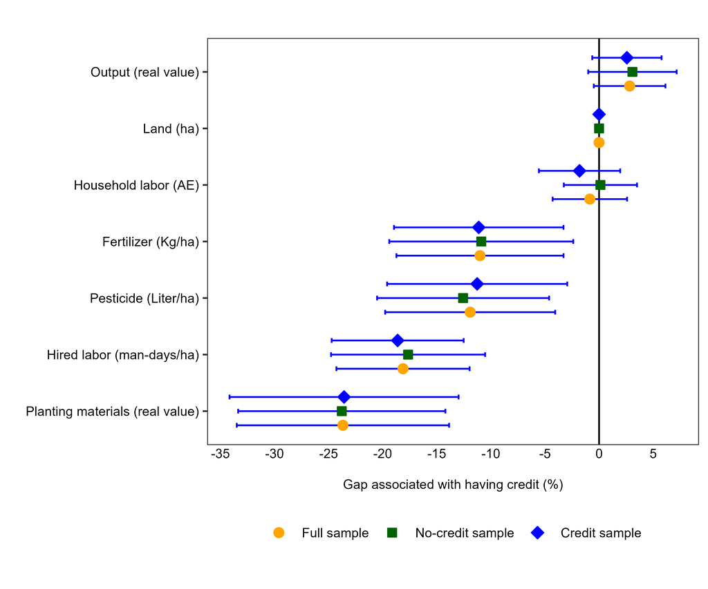

*Note:* Markers are the proportional gap associated with household credit use, estimated on the one-to-one matched pairs as log-linear treatment effects, and whiskers show jackknife uncertainty. Each outcome is estimated three times: over the full matched sample, over the covariate distribution of non-users and over that of users. Inputs are per hectare; output and planting material are real values. Jackknife uncertainty is from 100 delete-one-enumeration-area replicates that re-run matching and estimation in every replicate (Section 4.5).

#### Figure 2. The association between credit access and farm productivity differs by level of financial inclusion

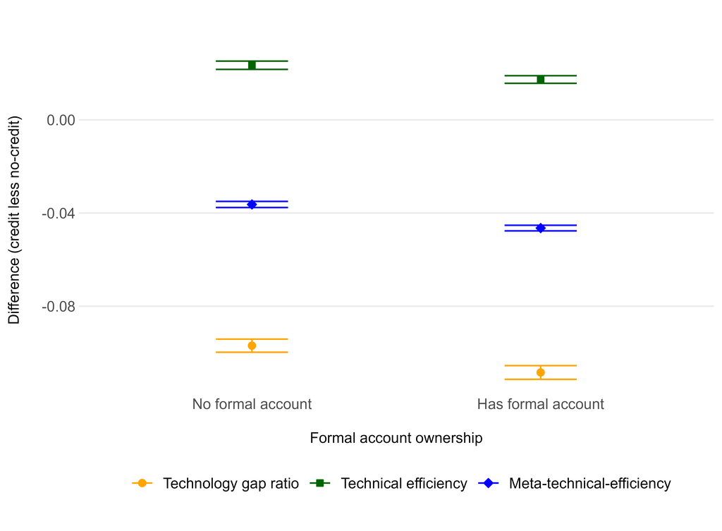

*Note:* Markers are the credit-user mean less the matched non-user mean, shown for the technology gap ratio, technical efficiency and meta-frontier technical efficiency, by whether the household holds an account with a financial institution or contributes to a savings scheme; whiskers show jackknife uncertainty. Scores are operator-level summaries drawn from the single matched meta frontier; the frontiers are not re-estimated by subgroup, so the estimates describe heterogeneity within the main result rather than separate models. Jackknife uncertainty is from 100 delete-one-enumeration-area replicates that re-run matching and estimation in every replicate (Section 4.5).

#### Figure 3. Credit parity in crop production technology adoption and technical efficiency by farmer gender, age, and education in Ghana (2012-2017)

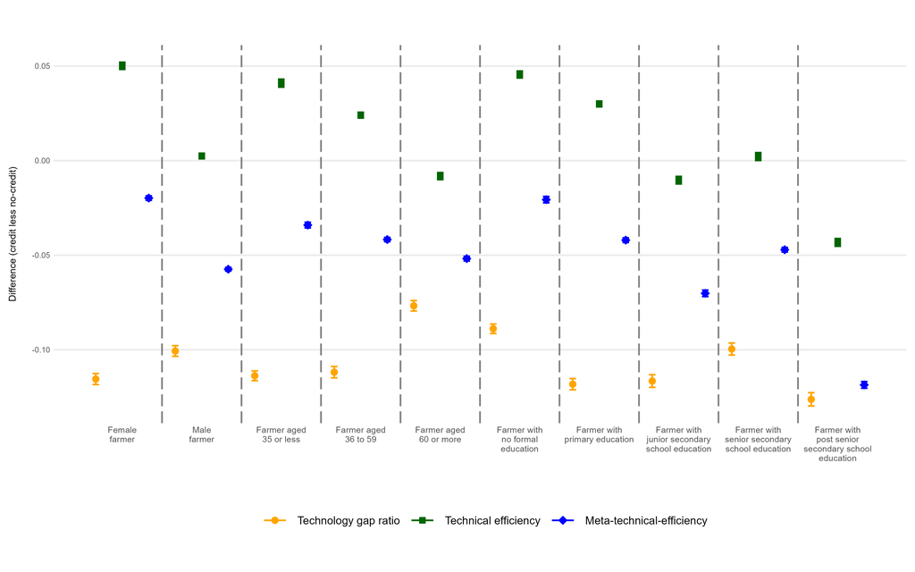

*Note:* Markers are the credit-user mean less the matched non-user mean for the three efficiency measures, by operator gender, age band and level of schooling; whiskers show jackknife uncertainty. Scores are operator-level summaries drawn from the single matched meta frontier; the frontiers are not re-estimated by subgroup, so the estimates describe heterogeneity within the main result rather than separate models. Jackknife uncertainty is from 100 delete-one-enumeration-area replicates that re-run matching and estimation in every replicate (Section 4.5).

#### Figure 4. Credit parity in crop production technology adoption and technical efficiency by major crops and administrative regions in Ghana (2012-2017)

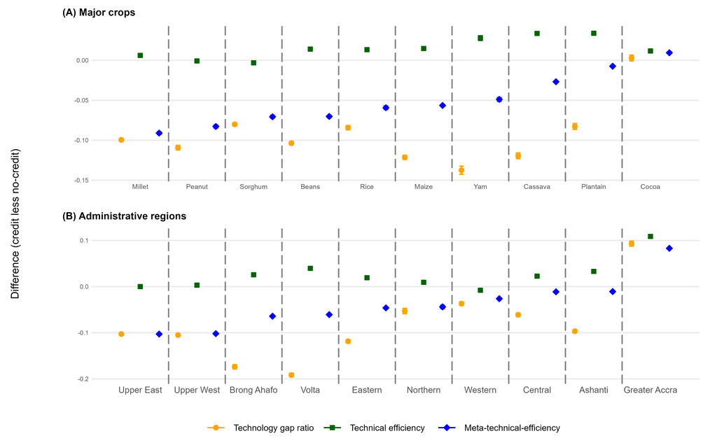

*Note:* Markers are the credit-user mean less the matched non-user mean for the three efficiency measures, by major crop and by administrative region of the period; whiskers show jackknife uncertainty. Scores are operator-level summaries drawn from the single matched meta frontier; the frontiers are not re-estimated by subgroup, so the estimates describe heterogeneity within the main result rather than separate models. Jackknife uncertainty is from 100 delete-one-enumeration-area replicates that re-run matching and estimation in every replicate (Section 4.5).

# Appendix

#### Note S1. Financial-Inclusion Index Construction

The financial-inclusion index introduced in Section 4.3 summarizes the non-credit dimensions of a farm household member’s engagement with financial services. It is built on one record per household member, with that member’s demographic characteristics averaged over the plots the member works, merged by enumeration area, household and member identifier to the harmonized financial-services release from which the indicators of Table S0 are drawn. The index is the first principal component of 14 indicators: the member’s years of schooling, whether the member works in a financial institution, whether another member of the household does, whether the member owns an account with a financial institution or contributes to a savings scheme, and ten indicators of insurance cover (vehicle, medical, funeral, property, commercial, travel, life, retirement, education and other endowment or investment plans). The component is fitted on complete cases across all 14 indicators; on the current release the financial indicators are themselves complete, so that restriction binds only through years of schooling, which is carried down from the farmer file. Composite measures of this kind are standard in work that treats financial inclusion as a multidimensional construct spanning accounts, savings and insurance rather than as account ownership alone, in Africa as elsewhere [1], [3].

Three indicators available in the same release were deliberately left out: the community distances to the nearest bank, motorable road and public transport (Table S0). Coverage is the first reason. The community questionnaire is administered per enumeration area and does not reach every area, so the three distances are missing for about a fifth of the members in the release, and the complete-case rule would drop every one of them. That loss is not random. It falls disproportionately on urban enumeration areas in 2012/13, which is precisely the imbalance the harmonization avoids by joining the community block to the farmer records rather than restricting to it, so admitting the distances here would reintroduce the same selection one stage later. Construct is the second reason. The distances describe a place rather than a person and enter with the sign opposite to every other indicator, so a component that included them would mix how financially connected a member is with how far that member lives from a bank. Excluding them makes the index unambiguously the former and removes the need to reason about sign when the loadings are read.

Because the two rounds differ in the services they record and rural and urban localities differ in the services available, a component is fitted separately within each survey-round-by-locality stratum rather than once over the pooled data: on 8,083 members in rural GLSS6, 1,527 in urban GLSS6, 5,692 in rural GLSS7 and 971 in urban GLSS7, against 16,273 in the pooled fit that supplies the reference metric. The sign and the scale of a principal component are arbitrary, so the four stratum scores are not comparable as estimated. Each is therefore placed on the pooled component’s metric by regressing the pooled score on the stratum score within the stratum and retaining the fitted values, a rescaling that fixes orientation as well as scale: where a stratum’s component came out sign-flipped, the regression coefficient is negative and the fitted values still align with the pooled score. The strata are disjoint, so the rescaled scores coalesce into a single value for every member. Three variables are released. `FinIdx` is the rescaled component itself. `FinIdxSi` is `FinIdx` min-max scaled over the pooled sample to the unit interval, and it is the variable that enters the matching distance of Section 4.3. `FinIdxCat` is the weighted quintiles of `FinIdx`, also taken over the pooled sample. Both transformations are pooled rather than within-round, so they express a member’s absolute position on the index and not a rank within a survey round; and because the scaling is min-max, `FinIdxSi` is by construction sensitive to a single extreme value, which compresses the remaining members into a narrower band than a rank or quantile transform would.

Table S6 reports the first-component loadings and the share of variance the component explains in each stratum, and they warrant a careful reading rather than a reassuring one. In the pooled fit every loading is positive and the two largest are on years of schooling and on account ownership, followed by life and vehicle insurance and by financial-sector employment, so the pooled metric is oriented in the direction the index’s name implies and the rescaling carries that orientation into every stratum. Two departures qualify this. Travel insurance has no variation in either 2016/17 stratum and is screened out of both, so the index rests on 14 indicators in 2012/13 and on 13 in 2016/17; taken with the fact that account ownership captures mobile money only in the later round, the index’s content is not identical across the two rounds. And one loading is negative: commercial insurance in the urban 2016/17 stratum. It is near enough to zero to carry little weight in the score, but a mixed sign pattern is the signal that a first component is picking up something other than inclusion, and it is reported here rather than smoothed over. The more consequential diagnostic is the explained variance. The first component accounts for about a seventh of the variance in a set of 14 indicators, where a component carrying no information at all would account for about a fourteenth. The component is therefore informative but far from dominant: the indicators it summarizes are only loosely correlated with one another, a single dimension does not come close to exhausting them, and a different indicator set or a different scaling would produce a different ordering of members. This is the substantiation of the limitation that Section 6 states, and it is the reason the index is used to balance a comparison rather than to carry an interpretation.

What the index is not, finally, is the treatment. The treatment throughout this paper is `credit_hh`, the household credit indicator defined in Section 2.2 and documented in Table S0. The index enters in two other roles: `FinIdxSi` is one covariate in the distance on which each credit-using household is paired with a non-user, so that borrowers are compared with non-borrowers of similar overall engagement with financial services (Section 4.3), and `FinIdxCat` is available in the estimation as a dimension of heterogeneity. No exhibit in this paper reports results by the index’s quintiles; heterogeneity across financial services is examined on the observed indicators themselves, formal account ownership above all (Figure 2 and Table 6). The index is estimated on 16,273 household-member records, a larger set than the 15,696 farm operators of the analysis sample, so index values exist for records the frontier analysis does not use; the matching draws on the values it needs and discards the rest.

#### Note S2. Construction and scope of the credit and financial-service indicators

The consolidated dataset does not carry the financial-services module, so the credit and financial-service indicators are rebuilt from the original GLSS questionnaires. Using the enumeration area, household and member identifiers preserved in both files, we extract the items of Part B, Section 12a (credit, banking, use of financial services and insurance) for every member of a farm household and merge them to the farmer-level file. Table S0 in the appendix documents, for each round, the source item, the question wording, the response options and the mapping to each analysis variable. These items serve three purposes in the paper: they define the credit indicator described next, they describe the financial-services environment of crop farmers in Section 3 (Tables 2 and 3), and they supply the dimensions along which Section 5 examines heterogeneity in the credit contrasts (Table 6 and Figure 2).

Credit use is defined for an individual as the conjunction of three conditions in the twelve months preceding the interview: the person applied for a loan (`s12aq7` in both rounds); the application was granted (`s12aq8` in GLSS6, `s12aq8a` to `s12aq8c` in GLSS7); and a positive loan amount was recorded (`s12aq10` in both rounds). Because the questionnaire elicits loan detail only from applicants whose loan was granted, requiring only a granted application, or only a positive amount, reproduces the indicator observation for observation; the conjunction matters for what it excludes rather than for what it includes. A person who applied and was refused, or whose application was still pending, is a non-user. Relaxing the criterion to any application regardless of outcome would raise the operator-level rate from 8.7% to 9.4%, but that is a different construct, one that pools refused and pending applicants with those who received funds.

Three features of what the indicator measures bear on how the results should be read. First, it records the use of credit, not access to it. The credit-constraints literature classifies households by direct elicitation of whether they were rationed, discouraged or unconstrained at prevailing terms [9], [10]; the GLSS module records refusals and, for non-applicants, the main reason for not applying (Table 3), but a household that could have borrowed and chose not to is pooled with one that could not borrow at all. The contrast we estimate is therefore between borrowers and non-borrowers rather than between the constrained and the unconstrained. Second, the indicator counts a loan from any source and for any purpose. Although the screening question refers to a loan from a financial institution, the source codes that follow include friends and relatives and group-based schemes, and Section 3 shows that these supply most of the loans farm households hold and that only a minority of loans are reported as taken for farming. The indicator should accordingly be read as household credit use rather than as agricultural credit, the construct that most of the Ghanaian studies reviewed in Section 1 examine [19], [20], [22], and household credit is fungible, so a loan reported for one purpose may finance another [24]. Third, the twelve-month recall window is not tied to the cropping calendar, so a loan may have been taken after the season’s input decisions were made.

Two asymmetries between the rounds bound the indicator further. The rounds do not code loan outcomes identically: GLSS6 records a binary granted or not granted, whereas GLSS7 adds a third status, “processing”, which the indicator treats as non-use because no loan had been disbursed. This status applies to 2.3% of GLSS7 applicants and has no GLSS6 counterpart, so cross-round comparisons of application outcomes in Section 3 set a two-way classification against a three-way one. In addition, GLSS7 elicits the status, source, purpose and collateral of up to three loans but records a single loan amount, so where an applicant reports several loans the amount cannot be attributed to a particular one; GLSS6, with one loan slot, has no such ambiguity. Neither asymmetry affects the treatment indicator, which depends only on whether some loan was granted and disbursed.

Credit is one dimension of financial inclusion, and the same module supplies the others. From Section 12a we also construct indicators of formal account ownership, the type of institution and account held, transaction products used and insurance cover, and, from the GLSS community questionnaire, the distance from the farmer’s community to the nearest bank, motorable road and public transport (Table S0). Section 3 uses these to describe the financial-services environment of crop farmers.

#### Note S3. The sample of crop producers, trends between rounds, and the profile of borrowing households

Operators cultivate at least one of banana, beans, cashew, cassava, citrus, cocoa, coconut, cocoyam, cotton/kenaf, maize, millet, oil palm, groundnut, plantain, potato, rice, sorghum, yam, sugarcane, tomato, pepper, okra, onion, eggplant, and other minor crops, and the sample spans the ten administrative regions of the period and all agro-ecological zones.

Table 1 summarizes the farmer, production and household characteristics of the pooled sample and of credit users and non-users, together with the annual percentage change in each characteristic between the two rounds; daggers mark characteristics on which users and non-users differ at the 5% level. The average operator is 47 years old with 4.5 years of schooling, and 27% of operators are women. Households average 5.4 adult equivalents with a dependency ratio of 1.42. Farms are small, at 2.31 ha on average, consistent with the smallholder profile reported in national statistics [49]; 69% of operators own the land they farm, and the crop diversification index averages 0.43. Mean crop output value is GH₵ 1,311 per hectare across all crops, with wide dispersion across crops. Purchased-input use is low and uneven: operators spend about GH₵ 171 per hectare on planting material, hire about 25 man-days per hectare, and apply about 332 kg of fertilizer and 25 liters of pesticide per hectare, the fertilizer and pesticide means being dominated by a small number of very large values, as their standard deviations show; only 5% use mechanized equipment and 2% irrigate. This is a production environment in which output depends chiefly on land and household labor, and in which the lumpy, liquidity-intensive investments that credit is expected to finance are the exception rather than the rule.

Credit users differ from non-users on a small number of characteristics, and they are the characteristics that matter most for who borrows and how farms perform. Users are younger (46.4 against 47.4 years) and markedly more educated (5.9 against 4.3 years), they are less likely to own the land they farm (68% against 70%), and they hire more labor per hectare (33 against 24 man-days). Output value per hectare across all crops does not differ significantly between the groups (GH₵ 1,345 against GH₵ 1,306), and neither do farm size, household size, the dependency ratio, crop diversification, the share of women among operators, planting-material expenditure, family labor, fertilizer or pesticide intensity, mechanization or irrigation. Where crop-specific output values differ, the sign is not uniform: non-users record higher values per hectare for rice, groundnut and yam, and users for cocoyam. On the observable production record, then, borrowers are not a systematically more productive or more input-intensive group; they are a younger, more schooled group that is less likely to own its land and relies more on hired labor.

The profile of borrowing households also depends on who in the household borrows (Table S1). Where the operator is the borrower, operators are younger (46.1 years) and more educated (6.2 years) than the pooled average, less likely to own their land (66%) and hire more labor per hectare. Where the spouse is the borrower, households are larger (6.8 adult equivalents against 5.4 in the pooled sample), more diversified and more likely to irrigate, and only 12% of operators are women, so spousal credit is in most such households a wife’s loan on a husband-operated farm. Households in which a child holds the credit are too few to support separate inference. These contrasts are one reason the household definition is preferred and the person-specific definitions are reported alongside it: restricting attention to the operator’s own borrowing would drop the spouse- and other-member-borrower households, which differ from operator-borrower households in size and cropping pattern.

#### Table S0. Construction of the credit and financial-service variables from the GLSS Section 12a questionnaires

[output not shown]

*Notes*: Items are drawn from Part B, Section 12a of each questionnaire (`sec12a` in GLSS6, `g7sec12a` in GLSS7); GLSS7 suffixes multi-response items with `_a`, `_b` and so on, which the harmonization strips. Wording is reproduced from the survey instruments. Loan detail is elicited only from respondents who applied and were granted a loan, so the credit indicator is the conjunction of application, approval and a positive amount rather than a test on the amount alone. Mobile money and susu accounts do not appear in the GLSS6 instrument, so their zero entries in Table 2 denote items not asked rather than an absence of holdings; the GLSS6 columns for the remaining institution and account items are re-indexed onto the GLSS7 positions before the rounds are pooled. GLSS7 records the status, source, purpose and collateral of up to three loans but a single loan amount, and adds a “processing” outcome that GLSS6 does not offer. The source-of-knowledge item is reported in Table 2 but is not discussed in the text; its derived category indicators do not currently reproduce the response order shown above, and the block is withheld from the narrative pending correction. Distances are taken from the community questionnaire rather than from Section 12a.

#### Table S1. Summary statistics of crop producers in Ghana (2012-2017)

| Variable | Pooled Pooled (n=15,696) | Person with credit Farmer (n=1,360) | Person with credit Spouse of farmer (n=635) | Person with credit Child (adopted or biological) (n=53) | Person with credit Spouse or child of farmer (n=676) | Person with credit Household member other than spouse or child (n=71) |
| --- | --- | --- | --- | --- | --- | --- |
| Farmer |  |  |  |  |  |  |
| Female farmer (dummy) | 0.27 (0.45) | 0.29 (0.45) | 0.12 (0.33) | 0.47 (0.50) | 0.15 (0.36) | 0.35 (0.48) † |
| Age (years) | 47.28 (15.21) | 46.07 (13.17) † | 47.26 (12.71) | 57.83 (13.25) † | 47.94 (13.02) | 39.86 (19.05) |
| Education (years) | 4.49 (5.19) | 6.20 (6.07) † | 5.28 (5.60) † | 3.92 (5.40) | 5.19 (5.62) † | 5.27 (5.21) |
| Selected crop production (real GH₵/ha) |  |  |  |  |  |  |
| All crops | 1310.98 (1689.59) | 1410.32 (1857.19) † | 1192.55 (1608.18) † | 1399.69 (1939.84) | 1218.58 (1647.51) | 1295.51 (1924.63) |
| Maize | 2533.77 (7248.51) | 2626.72 (7319.45) | 1653.50 (4006.09) | 5988.53 (14149.28) | 1976.42 (5510.26) | 1921.70 (4459.31) |
| Rice | 1185.00 (2042.43) | 1214.09 (2286.53) | 1087.79 (1423.06) | 1324.85 (1327.36) | 1104.11 (1418.94) | 1111.32 (1259.05) |
| Millet | 896.05 (1337.04) | 900.90 (1220.31) | 834.50 (1015.87) | 594.70 (508.80) | 832.30 (998.18) | 486.89 (335.91) |
| Sorghum | 883.42 (1223.87) | 904.09 (1173.91) | 902.22 (1028.96) | 428.24 (253.81) | 885.30 (1008.56) | 751.42 (1056.08) |
| Beans | 949.03 (1719.12) | 1083.62 (1980.48) | 1139.54 (2452.81) | 910.59 (1682.81) | 1129.34 (2400.97) | 461.93 (528.08) |
| Peanut | 1240.82 (2507.11) | 1121.17 (1770.58) † | 1144.30 (2108.27) † | 1385.43 (1761.19) | 1167.62 (2095.20) † | 896.26 (1077.06) |
| Cassava | 1358.30 (2777.46) | 1353.71 (2953.26) | 1025.94 (2130.58) | 1965.68 (4136.04) | 1122.21 (2405.06) | 1480.33 (1991.08) |
| Yam | 1635.38 (2878.35) | 1383.38 (2985.29) | 1605.16 (3175.75) | 296.52 (266.09) | 1520.44 (3083.83) | 2257.41 (5435.62) |
| Cocoyam | 477.47 (1065.11) | 596.16 (1106.20) | 530.76 (1178.30) | 279.02 (256.05) | 524.14 (1115.96) | 127.02 |
| Plantain | 1038.02 (2062.85) | 1062.55 (2115.86) | 948.92 (1724.13) | 1688.75 (2940.27) | 1053.90 (1898.02) | 912.01 (1675.97) |
| Pepper | 665.18 (1473.56) | 555.21 (1267.73) | 795.76 (2133.72) | 948.92 (1285.68) | 830.03 (2106.52) | 442.16 (620.26) |
| Okra | 351.63 (659.73) | 283.38 (555.07) | 344.77 (814.98) | 11.81 | 328.12 (796.73) | 1151.38 |
| Tomato | 528.77 (1282.13) | 663.27 (1121.94) | 678.25 (1309.29) |  | 678.25 (1309.29) | 15.34 |
| Cocoa | 650.94 (1594.78) | 599.22 (1267.25) | 552.93 (1020.53) | 334.62 (168.87) | 545.74 (996.08) | 372.34 (296.61) |
| Palm | 1139.80 (3473.80) | 1061.34 (2562.19) | 1554.05 (4322.56) | 7215.22 (16526.89) | 2396.93 (7349.21) † | 1263.11 (1623.33) |
| Land (ha) | 2.31 (2.91) | 2.46 (2.99) † | 2.49 (2.82) | 2.83 (3.66) | 2.47 (2.84) | 2.15 (2.94) |
| Land owned (dummy) | 0.69 (0.46) | 0.66 (0.47) † | 0.70 (0.46) † | 0.74 (0.45) | 0.71 (0.45) † | 0.73 (0.45) |
| Crop diversification (index) | 0.43 (0.27) | 0.42 (0.27) † | 0.48 (0.25) | 0.49 (0.27) † | 0.48 (0.25) † | 0.54 (0.28) † |
| Seed (real GH₵/ha) | 170.70 (771.64) | 165.06 (819.74) | 114.23 (293.09) | 77.17 (253.64) | 112.22 (292.59) | 77.97 (110.37) |
| Household labor (AE) | 9.07 (7.97) | 9.47 (8.13) | 11.90 (9.73) | 16.88 (11.60) † | 12.18 (9.91) † | 12.36 (10.78) |
| Hired labor (man-days/ha) | 25.16 (89.35) | 34.02 (100.66) † | 32.07 (89.10) | 11.80 (19.34) † | 30.83 (86.63) | 41.69 (124.30) |
| Fertilizer (Kg/ha) | 332.49 (8057.80) | 364.91 (1043.31) † | 404.78 (1042.00) | 238.75 (560.85) | 396.11 (1021.58) | 193.10 (313.94) † |
| Pesticide (Liter/ha) | 24.72 (336.93) | 63.77 (1130.45) | 24.29 (44.70) | 19.78 (28.96) | 23.88 (43.93) | 11.99 (21.26) |
| Mechanization (dummy) | 0.05 (0.21) | 0.05 (0.23) | 0.10 (0.30) † | 0.04 (0.19) | 0.10 (0.30) † | 0.08 (0.28) |
| Irrigation (dummy) | 0.02 (0.14) | 0.03 (0.18) | 0.04 (0.19) | 0.02 (0.14) | 0.04 (0.19) | 0.01 (0.12) |
| Household |  |  |  |  |  |  |
| Size (AE) | 5.37 (3.14) | 5.44 (2.95) | 6.81 (3.24) † | 8.39 (3.97) † | 6.87 (3.25) † | 7.33 (3.19) † |
| Dependency (ratio) | 1.42 (1.71) | 1.47 (1.74) | 1.55 (1.60) | 1.70 (2.02) | 1.56 (1.65) | 1.97 (2.03) |

Significance levels: * p<0.10, ** p<0.05, *** p<0.01.  
Standard deviations in parentheses. A dagger denotes a statistically significant difference from the pooled sample.  
Data source: Ghana Living Standards Survey [waves 6-7].

#### Table S2. Trends in the characteristics of crop producers in Ghana (2012-2017)

| Variable | Pooled Pooled (n=15,696) | Person with credit Farmer (n=1,360) | Person with credit Spouse of farmer (n=635) | Person with credit Child (adopted or biological) (n=53) | Person with credit Spouse or child of farmer (n=676) | Person with credit Household member other than spouse or child (n=71) |
| --- | --- | --- | --- | --- | --- | --- |
| Farmer |  |  |  |  |  |  |
| Female farmer (dummy) | -2.94*** [0.63] | 1.64 [2.13] † | -34.69*** [6.59] † | 5.54 [7.51] | -23.63*** [5.01] † | -19.33* [11.25] |
| Age (years) | 0.70*** [0.13] | 0.81** [0.40] | 1.84*** [0.53] † | 1.02 [1.59] | 1.72*** [0.52] † | -1.40 [3.19] |
| Education (years) | 1.57*** [0.48] | -2.33* [1.38] † | -6.04*** [2.22] † | 14.29 [11.94] | -5.20** [2.19] † | -3.99 [6.98] |
| Selected crop production (real GH₵/ha) |  |  |  |  |  |  |
| All crops | 9.65*** [0.58] | 7.38*** [1.92] | 12.61*** [2.87] | -1.52 [8.46] | 11.32*** [2.76] | -5.17 [9.93] |
| Maize | 30.44*** [2.21] | 24.91*** [6.24] | 23.72*** [7.08] † | 90.07 [234.66] | 30.60*** [9.80] | 10.64 [19.20] |
| Rice | 12.92*** [1.92] | 5.88 [4.49] | 1.41 [4.48] † |  | 0.47 [4.35] † |  |
| Millet | 1.55 [1.30] | 1.15 [5.07] | 5.74 [6.17] |  | 6.53 [6.14] |  |
| Sorghum | 0.98 [1.44] | 4.69 [5.24] | -5.34 [5.35] |  | -4.77 [5.16] |  |
| Beans | 8.89*** [1.61] | 7.13 [5.01] | 10.98 [7.73] |  | 9.70 [7.42] |  |
| Peanut | 17.59*** [1.83] | 3.96 [4.52] † | 1.49 [5.56] † |  | 0.00 [5.43] † |  |
| Cassava | 127.03 [543.89] | 220.27 [521.29] | 731.80 [13120.08] |  | -20.16 [156.49] |  |
| Yam | 175.22 [113.08] | -122.55 [498.97] | 3.75 [54.83] |  | -3.87 [62.58] |  |
| Cocoyam | 36.31 [53.36] | 84.70** [37.20] |  |  |  |  |
| Plantain | 57.83 [60.39] | 826.72 [11885.12] | -19.64 [200.06] |  | 20.65 [62.36] |  |
| Pepper | -23.00 [50.85] | -2.09 [71.61] | 67.82 [78.69] |  | 69.87 [77.49] |  |
| Okra | 6.90 [4.24] | -11.32 [16.33] |  |  |  |  |
| Tomato | 7.69 [10.40] |  |  |  |  |  |
| Cocoa | 35.39*** [4.24] | 25.68** [10.29] | 29.49* [17.83] |  | 29.26* [17.68] |  |
| Palm | -831.40 [17464.44] | 59.17* [34.86] | 192.85** [90.39] |  | 145.35** [63.95] |  |
| Land (ha) | -1.59*** [0.50] | -3.37** [1.61] | 1.54 [2.43] | -7.84 [9.29] | 1.31 [2.38] | -0.77 [6.30] |
| Land owned (dummy) | 1.89*** [0.28] | 3.33*** [1.01] | 8.09*** [1.56] † | 4.02 [4.86] | 7.70*** [1.49] † | 6.67 [4.36] |
| Crop diversification (index) | -2.41*** [0.26] | -1.32 [0.87] | 0.23 [1.02] † | -8.46** [4.14] | -0.40 [0.99] | -5.89 [3.73] |
| Seed (real GH₵/ha) | 39.63*** [3.61] | 39.58*** [13.06] | 21.83*** [7.34] † | 36.08 [45.89] | 22.94*** [7.43] † | 4.69 [8.91] † |
| Household labor (AE) | 4.57*** [0.37] | 4.55*** [1.24] | 9.80*** [1.78] † | -7.71 [4.94] † | 8.48*** [1.71] † | 9.67 [6.41] |
| Hired labor (man-days/ha) | 1.52 [1.53] | -12.40*** [3.39] † | 0.23 [5.13] | -4.33 [12.70] | 0.11 [5.03] | -15.87 [11.77] |
| Fertilizer (Kg/ha) | 22.03* [13.10] | 8.69** [3.84] | 24.18*** [5.32] | 12.45 [18.90] | 23.18*** [5.18] | 47.48** [21.54] |
| Pesticide (Liter/ha) | 4.14 [4.11] | 36.45 [42.24] | -3.24 [4.06] | -2.32 [9.71] | -3.19 [3.93] | -9.45 [8.88] |
| Mechanization (dummy) | -5.10*** [1.95] | 12.10** [6.06] † | 6.21 [6.32] |  | 4.69 [6.25] |  |
| Irrigation (dummy) | -2.49 [3.09] | 0.33 [7.52] | 12.48 [9.60] |  | 12.65 [9.62] |  |
| Household |  |  |  |  |  |  |
| Size (AE) | -0.51** [0.26] | 1.41* [0.75] † | 3.78*** [0.97] † | -2.18 [3.10] | 3.56*** [0.94] † | -2.35 [2.50] |
| Dependency (ratio) | -1.92*** [0.52] | -0.53 [1.59] | 0.34 [2.21] | -4.42 [7.13] | -0.11 [2.16] | 1.28 [5.81] |

Significance levels: * p<0.10, ** p<0.05, *** p<0.01.  
Annual percentage change; standard errors in brackets. A dagger denotes a statistically significant difference from the pooled sample.  
Data source: Ghana Living Standards Survey [waves 6-7].

#### Table S3. Meta stochastic frontier analysis results for Ghanaian crop producers, 2012/13 and 2016/17

|  | National Naive national frontier | Group frontier No credit | Group frontier Some credit | Meta-frontier Matched | Meta-frontier Unmatched |
| --- | --- | --- | --- | --- | --- |
| Production function |  |  |  |  |  |
| Land [lnI1] | 0.791*** (0.001) | 0.785*** (0.001) | 0.873*** (0.001) | 0.759*** (0.003) | 0.784*** (0.003) |
| Planting material [lnI2] | 0.041*** (0.000) | 0.041*** (0.000) | 0.040*** (0.000) | 0.040*** (0.000) | 0.041*** (0.000) |
| Family labor [lnI3] | 0.152*** (0.000) | 0.154*** (0.001) | 0.121*** (0.002) | 0.131*** (0.003) | 0.146*** (0.001) |
| Hired labor [lnI4] | 0.024*** (0.000) | 0.025*** (0.000) | 0.018*** (0.000) | 0.025*** (0.000) | 0.024*** (0.001) |
| Fertilizer [lnI5] | 0.022*** (0.000) | 0.021*** (0.000) | 0.026*** (0.000) | 0.021*** (0.000) | 0.021*** (0.000) |
| Pesticide [lnI6] | 0.021*** (0.000) | 0.021*** (0.000) | 0.022*** (0.000) | 0.021*** (0.000) | 0.020*** (0.000) |
| 1/2 * lnI1 * lnI1 | 0.076*** (0.001) | 0.073*** (0.001) | 0.088*** (0.001) | 0.099*** (0.002) | 0.077*** (0.001) |
| lnI1*lnI2 | 0.000 (0.000) | -0.000 (0.000) | 0.000 (0.000) | -0.000 (0.000) | 0.000 (0.000) |
| lnI1*lnI3 | -0.053*** (0.000) | -0.054*** (0.000) | -0.061*** (0.000) | -0.049*** (0.001) | -0.051*** (0.001) |
| lnI1*lnI4 | -0.000 (0.000) | -0.000 (0.000) | 0.000 (0.000) | -0.001*** (0.000) | -0.000*** (0.000) |
| lnI1*lnI5 | 0.000 (0.000) | 0.000 (0.000) | 0.000* (0.000) | 0.001*** (0.000) | -0.000*** (0.000) |
| lnI1*lnI6 | -0.000 (0.000) | 0.000 (0.000) | 0.000 (0.000) | 0.000*** (0.000) | 0.000*** (0.000) |
| 1/2 * lnI2 * lnI2 | 0.004*** (0.000) | 0.004*** (0.000) | 0.003*** (0.000) | 0.003*** (0.000) | 0.004*** (0.000) |
| lnI2*lnI3 | -0.000 (0.000) | -0.000 (0.000) | 0.000 (0.000) | -0.000 (0.000) | 0.000 (0.000) |
| lnI2*lnI4 | 0.000 (0.000) | 0.000 (0.000) | -0.000 (0.000) | -0.000 (0.000) | -0.000* (0.000) |
| lnI2*lnI5 | -0.000 (0.000) | -0.000 (0.000) | -0.000 (0.000) | 0.000 (0.000) | -0.000*** (0.000) |
| lnI2*lnI6 | -0.000 (0.000) | 0.000 (0.000) | -0.000 (0.000) | -0.000 (0.000) | -0.000 (0.000) |
| 1/2 * lnI3 * lnI3 | 0.019*** (0.000) | 0.019*** (0.000) | 0.036*** (0.001) | 0.028*** (0.001) | 0.021*** (0.000) |
| lnI3*lnI4 | 0.000 (0.000) | -0.000 (0.000) | 0.000* (0.000) | 0.000 (0.000) | 0.000 (0.000) |
| lnI3*lnI5 | 0.000 (0.000) | -0.000 (0.000) | -0.000 (0.000) | 0.000*** (0.000) | 0.000*** (0.000) |
| lnI3*lnI6 | -0.000 (0.000) | -0.000 (0.000) | -0.000** (0.000) | -0.000 (0.000) | -0.000*** (0.000) |
| 1/2 * lnI4 * lnI4 | 0.002*** (0.000) | 0.002*** (0.000) | 0.002*** (0.000) | 0.002*** (0.000) | 0.002*** (0.000) |
| lnI4*lnI5 | 0.000 (0.000) | 0.000 (0.000) | 0.000* (0.000) | -0.000*** (0.000) | 0.000 (0.000) |
| lnI4*lnI6 | 0.000 (0.000) | -0.000 (0.000) | 0.000 (0.000) | 0.000** (0.000) | 0.000 (0.000) |
| 1/2 * lnI5 * lnI5 | 0.002*** (0.000) | 0.002*** (0.000) | 0.002*** (0.000) | 0.002*** (0.000) | 0.002*** (0.000) |
| lnI5*lnI6 | -0.000 (0.000) | 0.000 (0.000) | -0.000** (0.000) | 0.000 (0.000) | 0.000* (0.000) |
| 1/2 * lnI6 * lnI6 | 0.002*** (0.000) | 0.002*** (0.000) | 0.002*** (0.000) | 0.002*** (0.000) | 0.002*** (0.000) |
| Proportion of area under listed crop (base = maize) |  |  |  |  |  |
| Cassava | -0.486*** (0.009) | -0.559*** (0.010) | -0.126*** (0.013) | -0.556*** (0.010) | -0.492*** (0.024) |
| Peanut | -0.459*** (0.009) | -0.536*** (0.009) | -0.067*** (0.013) | -0.509*** (0.010) | -0.465*** (0.022) |
| Plantain | -0.468*** (0.009) | -0.558*** (0.009) | -0.074*** (0.013) | -0.518*** (0.010) | -0.476*** (0.019) |
| Rice | -0.439*** (0.009) | -0.515*** (0.010) | -0.056*** (0.013) | -0.488*** (0.010) | -0.445*** (0.024) |
| Millet | -0.437*** (0.009) | -0.512*** (0.009) | -0.110*** (0.013) | -0.487*** (0.010) | -0.444*** (0.024) |
| Sorghum | -0.449*** (0.009) | -0.526*** (0.010) | 0.064*** (0.013) | -0.450*** (0.009) | -0.455*** (0.024) |
| Beans | -0.443*** (0.009) | -0.521*** (0.009) | -0.033** (0.013) | -0.502*** (0.010) | -0.449*** (0.024) |
| Yam | -0.451*** (0.009) | -0.506*** (0.009) | -0.101*** (0.034) | -0.506*** (0.010) | -0.458*** (0.016) |
| Cocoa | -0.117*** (0.009) | -0.216*** (0.009) | 0.553*** (0.013) | 0.032*** (0.010) | -0.133*** (0.011) |
| Other | -0.472*** (0.009) | -0.547*** (0.010) | -0.108*** (0.013) | -0.535*** (0.010) | -0.478*** (0.024) |
| Ecological zone (base = Coastal Savannah) |  |  |  |  |  |
| Forest | 0.467*** (0.004) | 0.467*** (0.004) | 0.421*** (0.008) | 0.458*** (0.004) | 0.466*** (0.004) |
| Guinea Savanah | -0.876*** (0.004) | -0.874*** (0.008) | -0.857*** (0.010) | -0.883*** (0.009) | -0.866*** (0.026) |
| Sudan Savanah | -0.892*** (0.004) | -0.891*** (0.004) | -0.946*** (0.009) | -0.887*** (0.005) | -0.895*** (0.004) |
| Transitional | -0.003 (0.004) | 0.005 (0.004) | -0.183*** (0.011) | 0.014*** (0.004) | -0.012 (0.013) |
| Intercept | 7.391*** (0.010) | 7.482*** (0.010) | 6.907*** (0.014) | 7.547*** (0.010) | 7.503*** (0.013) |
| Production risk function |  |  |  |  |  |
| Intercept | -0.514*** (0.001) | -0.518*** (0.001) | -0.522*** (0.004) | -8.107*** (0.317) | -7.285*** (0.481) |

Significance levels: * p<0.10, ** p<0.05, *** p<0.01.  
Jackknife standard errors in parentheses.  
Restricted specification.  
Data source: Ghana Living Standards Survey [waves 6-7].

#### Table S4. Determinants of crop production technical inefficiency and credit-driven technology gaps in Ghana (2012-2017)

|  | National Naive national frontier | Group frontier No credit | Group frontier Some credit | Meta-frontier Matched | Meta-frontier Unmatched |
| --- | --- | --- | --- | --- | --- |
| Female farmer (dummy) | 0.511*** (0.002) | 0.528*** (0.002) | 0.397*** (0.006) | 0.876*** (0.016) | 0.189 (0.212) |
| Age (years) | 0.134*** (0.003) | 0.106*** (0.003) | 0.266*** (0.012) | -0.395*** (0.024) | -0.068** (0.032) |
| Education (years) | 0.013*** (0.000) | 0.012*** (0.000) | 0.019*** (0.001) | 0.028*** (0.001) | 0.013 (0.012) |
| Land owned (dummy) | -0.142*** (0.003) | -0.149*** (0.003) | -0.010 (0.006) | -0.368*** (0.013) | 0.014 (0.131) |
| Crop diversification (index) | 0.158*** (0.005) | 0.202*** (0.005) | -0.107*** (0.010) | -1.331*** (0.024) | -0.117 (0.332) |
| Mechanization (dummy) | -0.353*** (0.012) | -0.928*** (0.027) | 0.977*** (0.017) | -0.667*** (0.041) | 0.103*** (0.034) |
| Extension (dummy) | -0.081*** (0.004) | -0.053*** (0.004) | -0.204*** (0.011) | -0.180*** (0.015) | -0.161 (0.171) |
| Ecological zone (base = Coastal Savannah) |  |  |  |  |  |
| Forest | 0.346*** (0.006) | 0.331*** (0.006) | 0.369*** (0.013) | -0.050 (0.044) | 0.081 (0.210) |
| Guinea Savanah | -73.589*** (23.042) | -8.085 (5.441) | -37.289*** (1.159) | -1.129*** (0.135) | 0.189 (3.189) |
| Sudan Savanah | -44.901*** (7.129) | -33.728 (91.163) | -37.045*** (0.848) | 1.019*** (0.046) | 0.000 (0.142) |
| Transitional | -0.010* (0.006) | -0.048*** (0.006) | 0.035 (0.026) | 1.113*** (0.076) | 0.112 (0.526) |
| Intercept | -0.180*** (0.013) | -0.070*** (0.012) | -0.763*** (0.048) | -1.449*** (0.104) | -6.118*** (0.888) |

Significance levels: * p<0.10, ** p<0.05, *** p<0.01.  
Jackknife standard errors in parentheses.  
Restricted specification.  
Data source: Ghana Living Standards Survey [waves 6-7].

#### Table S5. Definition, measurement and expected sign of the variables in the frontier, inefficiency and matching specifications

[output not shown]

#### Table S6. First-component loadings and explained variance for the financial-inclusion index, by stratum

| Indicator | Pooled | Survey round and locality GLSS6 Rural | Survey round and locality GLSS6 Urban | Survey round and locality GLSS7 Rural | Survey round and locality GLSS7 Urban |
| --- | --- | --- | --- | --- | --- |
| Years of schooling | 0.391 | 0.380 | 0.294 | 0.391 | 0.359 |
| Account ownership or scheme contribution | 0.373 | 0.374 | 0.278 | 0.362 | 0.297 |
| Life insurance | 0.353 | 0.396 | 0.275 | 0.262 | 0.363 |
| Works in the financial sector | 0.293 | 0.171 | 0.391 | 0.288 | 0.334 |
| Vehicle insurance | 0.292 | 0.324 | 0.270 | 0.357 | 0.072 |
| Pension insurance | 0.286 | 0.363 | 0.173 | 0.242 | 0.105 |
| Household member works in the financial sector | 0.279 | 0.154 | 0.352 | 0.293 | 0.332 |
| Education insurance | 0.233 | 0.342 | 0.090 | 0.217 | 0.412 |
| Business insurance | 0.216 | 0.041 | 0.442 | 0.227 | -0.028 |
| Investment insurance | 0.208 | 0.091 | 0.332 | 0.351 | 0.108 |
| Death insurance | 0.207 | 0.293 | 0.057 | 0.201 | 0.429 |
| Health insurance | 0.187 | 0.158 | 0.140 | 0.149 | 0.206 |
| Asset insurance | 0.164 | 0.137 | 0.211 | 0.093 | 0.067 |
| Travel insurance | 0.061 | 0.118 | 0.010 | — | — |
| Component diagnostics |  |  |  |  |  |
| Indicators entering the component | 14 | 14 | 14 | 13 | 13 |
| Observations | 16,235 | 8,072 | 1,518 | 5,677 | 968 |
| Share of variance explained | 0.140 | 0.140 | 0.166 | 0.139 | 0.148 |

Entries are loadings on the first principal component, estimated over the pooled sample and separately within each survey-round-by-locality stratum by 000_INDEX_financial_inclusion_study.do. GLSS6 is the 2012/13 round and GLSS7 the 2016/17 round.  
Rows are ordered by the pooled loading, largest first. An em dash marks an indicator that does not enter a stratum's component: it has no variation in that stratum and is screened out before estimation, so the loading is absent rather than zero, as with travel insurance. The component rests on 14 indicators in 2012/13 and 13 in 2016/17, so its content is not identical across the two rounds.  
Loadings are as estimated within each stratum, before the stratum scores are placed on the pooled component's metric. The sign and scale of a principal component are arbitrary, so a sign pattern is informative within a column and not across columns; in the pooled fit every loading is positive, so a higher index score means greater financial inclusion, and the rescaling carries that orientation into every stratum (Note S1).  
The share of variance explained is the proportion of the total variance of the indicator set carried by the first component. With 14 indicators, a component carrying no more than an equal share would account for about 0.071.  
Observations are household-member records. The index is estimated on more records than the analysis sample of farm operators uses; the matching draws the values it needs (Note S1).  
Data source: Ghana Living Standards Survey [waves 6-7].

#### Table S7. The financial-inclusion index among Ghanaian crop farmers, by survey round, locality, credit use, account ownership and region

| Group | Index mean (sd) | Share in top fifth | Operators |
| --- | --- | --- | --- |
| All crop farmers | 0.034 (0.037) | 0.200 | 15,696 |
| Survey round |  |  |  |
| 2012/13 | 0.033 (0.038) | 0.192 | 9,265 |
| 2016/17 | 0.034 (0.034) | 0.212 | 6,431 |
| Locality |  |  |  |
| Rural | 0.031 (0.033) | 0.165 | 13,331 |
| Urban | 0.048 (0.051) | 0.400 | 2,365 |
| Household credit use |  |  |  |
| No credit | 0.032 (0.031) | 0.181 | 13,829 |
| Some credit | 0.050 (0.063) | 0.342 | 1,867 |
| Formal account |  |  |  |
| No account | 0.022 (0.015) | 0.021 | 10,876 |
| Has account | 0.061 (0.053) | 0.604 | 4,820 |
| Region |  |  |  |
| Eastern | 0.041 (0.037) | 0.292 | 1,615 |
| Brong Ahafo | 0.040 (0.036) | 0.303 | 1,796 |
| Volta | 0.040 (0.042) | 0.255 | 1,630 |
| Western | 0.039 (0.038) | 0.269 | 1,276 |
| Greater Accra | 0.039 (0.030) | 0.340 | 103 |
| Ashanti | 0.039 (0.031) | 0.306 | 1,129 |
| Central | 0.037 (0.027) | 0.255 | 1,118 |
| Upper East | 0.030 (0.040) | 0.122 | 2,205 |
| Upper West | 0.028 (0.043) | 0.110 | 2,249 |
| Northern | 0.023 (0.026) | 0.072 | 2,575 |
| Regional extremes |  |  |  |
| Highest region | 0.041 (0.037) | 0.292 | 1,615 |
| Lowest region | 0.023 (0.026) | 0.072 | 2,575 |

The financial-inclusion index is the min-max scaled first principal component of the non-credit financial-service indicators of Table S6, fitted within survey-round-by-locality strata and placed on the metric of the pooled component (Note S1). It runs from 0 for the least to 1 for the most financially connected operator in the pooled sample, so its level is a position within this sample rather than an absolute measure of inclusion.  
Entries are unweighted means over farm operators, with standard deviations in parentheses. The top fifth is the highest 20% of the pooled index distribution; the share is the proportion of the group's operators in it, so the pooled row is 0.200 by construction. The highest and lowest regional means are Eastern and Northern.  
Groups are not mutually exclusive across blocks: every operator appears once in each block that applies. Regions are ordered by the group mean, largest first.  
Data source: Ghana Living Standards Survey [waves 6-7].

#### Figure S1. Covariate balancing summary

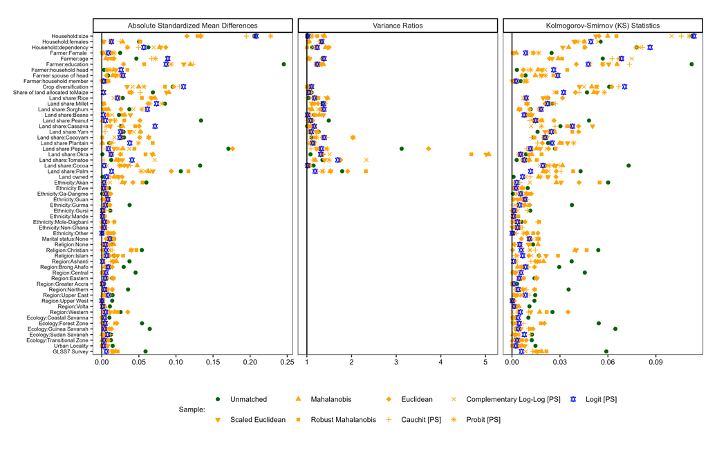

*Note:* Each panel reports one balance diagnostic for every matching covariate: the absolute standardized mean difference, the variance ratio and the Kolmogorov-Smirnov statistic, whose targets are zero, one and zero respectively. Markers distinguish the unmatched sample from each of the eight matched samples of Section 4.3. The probit propensity-score sample, which ranks best on a composite of the three diagnostics, underlies Tables 4 to 6 and Figures 1 to 4.

#### Figure S2. Different model specifications generally show decreasing impact of farmer credit access on crop production output for Ghanaian farmers (2012-2017)

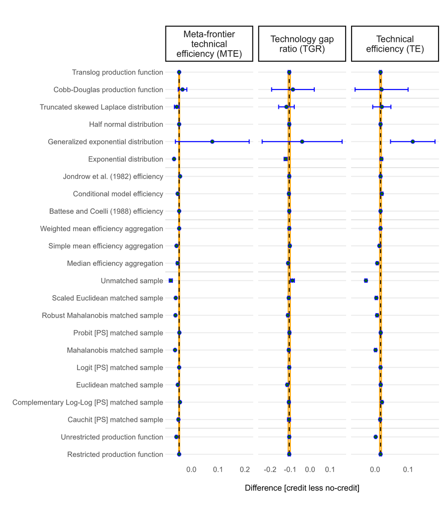

*Note:* Each row re-estimates the three credit-less-no-credit differences under one alternative specification, grouped by functional form, inefficiency distribution, efficiency estimator, aggregation rule, matched sample and regularity restriction; whiskers show jackknife uncertainty. The dashed line and shaded band mark the preferred specification reported in Table 4: a Translog frontier with a half-normal inefficiency term, Battese-Coelli scores aggregated by the weighted mean on the probit matched sample, with the regularity restrictions imposed. The truncated normal is absent because it returns no usable estimate (Section 5.5).